# Statistics and Probability

# 1 Statistical models and method-of-moments

## 1.1 About the course

This course will teach you the basic concepts of statistics: estimation, hypothesis testing and confidence intervals. It will *not* teach you how to analyze a real data set, but you will learn about that in the other courses of the program.

The philosophy of the course is to make things practical and intuitive. Often, there are multiple ways to arrive at the same result: a mathematical derivation and an implementation in R. The mathematical derivation will give more precise results, but can quickly get difficult unless the models are very simple. We feel that the derivations using R are often more intuitive, since they are more visual. We will often prioritize this way.

The R code we use is simple (some may say simplistic) and sometimes inefficient. This is intentional, because we want it to remain close to the concepts. You will learn to write much better R code in other courses than this one.

### 1.1.1 How to learn?

We kept the text to a minimum, but that does mean that every word is important. The exercises that follow the text are supposed to help you truly understand what you just read. *Don’t* skip over them, and don’t click too quickly for the answer because you’ll miss your only opportunity to really learn the material. The exercises also give you guidance for the kind of problems you have to be able to solve on the exam. The mathematical solutions to problems you need to be able to do in simple cases like the ones we discuss in the examples and exercises. The R-based solutions will form your general toolbox with which you can solve questions in more complex models.

## 1.2 What is statistics?

In the last few lectures we learned about probability theory. In a birds-eye view, probability theory allows us to calculate the probability of certain events happening. The starting point is always a probability distribution, which is given. What we calculate is the probability that a certain event happens.

$~$

#### 1.2.0.1 Exercise

Suppose $X$ has a Poisson distribution with $\lambda$. If $\lambda=4$, what is the probability that we observe the values $X=1,3,4,2$ from this distribution?

**Click for the answer**

```r
X <- c(1,3,4,2)
prod(dpois(X, lambda=4))  #prod because of the iid assumption
```

```
## [1] 0.0004097281
```

```r
# alternatively, without dpois:
lambda <- 4
probs <- lambda^X * exp(-lambda) / factorial(X)
prod(probs)
```

```
## [1] 0.0004097281
```

$~$

In probability theory we reason from the probability distribution to the data. Inferential statistics is essentially the reverse of this. We observe the data, but we do not know what the probability distribution is. We try to *reverse engineer* the probability distribution from the observed data. We reason from the data to the probability distribution. In statistical terminology, the data are often called the *sample* and the probability distribution the *population*. So in statistics we reason from from the sample to the population.

$~$

#### 1.2.0.2 Exercise

Suppose $X$ has a Poisson distribution with $\lambda$. If we observe $X=1,3,4,2$. Make a guess of the value of $\lambda$ do you think could have been the one that generated the data $X$? Motivate your guess.

**Click for the answer**

In the Poisson distribution, lambda determines the average count. In the data we have an average count of 2.5 So a Poisson distribution with $\lambda=2.5$ would fit the data reasonably well. This is the method-of-moments reasoning to find lambda. We will learn about method of moments later this lecture.

Alternative answer:

```r
# We see that we have a low probability of getting these data when lambda=4:
prod(dpois(X, lambda=4))
```

```
## [1] 0.0004097281
```

```r
# What values of lambda have more chance of producing these data?
prod(dpois(X, lambda=3.5))
```

```
## [1] 0.0007964623
```

```r
prod(dpois(X, lambda=3))
```

```
## [1] 0.001259756
```

```r
prod(dpois(X, lambda=2.5))
```

```
## [1] 0.001503359
```

```r
prod(dpois(X, lambda=2))
```

```
## [1] 0.001192756
```

```r
prod(dpois(X, lambda=1.5))
```

```
## [1] 0.0004963102
```

So maybe $\lambda=2.5$ fits the data best This is a maximum likelihood reasoning for finding lambda. We will learn about this during a later lecture.

$~$

In the rest of the course we are going to make this central question, what probability distribution could have generated the data, much more precise and find ways to answer it. In statistics, there are three standard ways of formulating questions about the probability distribution: estimation, testing and confidence intervals. Below are some examples of these three types of question.

- Estimation: what single value of $\lambda$ is the most likely to have generated $X$?
- Testing: could $\lambda = 7$ have generated $X$?
- Confidence intervals: what range of values of $\lambda$ is compatible with $X$?

$~$

#### 1.2.0.3 Exercise

Explain in your own words why statisticians are more interested in the underlying probability distribution, rather than in the data themselves?

**Click for the answer**

In very brief: The probability distribution allows us to generalize: through the distribution we learn to experimental units we have not observed yet. Patterns we see in the sample but not in the population are not reproducible

$~$

The distinction between population and sample is one of the most central concepts of statistics. We make a distinction between *descriptive statistics* that describe the sample (the data) and *inferential statistics* that describe our knowledge (or the lack of it!) about the population (the probability distribution underlying the data). This course is about inferential statistics.

## 1.3 Statistical models

Statistics reasons from the data to a probability distribution, but it cannot do so without making at least some *assumptions* about this probability distribution.

In most experiments or studies the gathering of data involves repeatedly measuring patients, experimental subjects, or mice. For each of these we measure the same thing such as their blood pressure, or whether they had breakfast. We call the patients, subjects or mice the sampling units, ans we assume we have we have $n$ of them. The measure data are then $X_1, X_2, \ldots, X_n$.

One basic set of assumptions is very often made:

- There exists a probability distribution $P$ such that each $X_i$ is a draw from $P$.
- The $X_1, X_2, \ldots, X_n$ are independent.

As a shorthand for this, we say that $X_1, X_2, \ldots, X_n$ are *iid*, where iid stands for “independent and identically distributed”. Equivalently, $X_1, X_2, \ldots, X_n$ are said to be a *sample* from $P$.

In more complex models, we will make the iid assumption not on all of the data, but only in part. For example, in a clinical trial we will assume that the data for the treated group are iid and for the placebo group. Between the groups the data will be independent, but not identically distributed (at least that is what the experimenter hopes!). In a regression model, we assume the errors, rather than the data themselves to be iid. Almost all statistical models involve an iid assumption somewhere.

Since this assumption is almost always made in statistics, it is sometimes implicit. Still, it is important to realize that this is really an assumption. It is often only approximately true.

$~$

#### 1.3.0.1 Exercise

In which of the following situations, what are the sampling units. Is it reasonable to assume that the sample is iid? What arguments can you give against it?

1. The saliva of all attendants at a dance club is tested for drugs.
2. I measure 24h precipitation every Monday at the same location for a year

**Click for the answer**

1. The measurement are not fully independent, because attendants may have come in groups they may have influenced each others drug use. The attendants may not have the same probability of use
2. Long-term weather paterns may make this week and next week’s rain correlated. The precipitation distribution varies by season.

$~$

The probability distribution $P$ is also referred to as the *population*. We imagine that $X_1, X_2, \ldots, X_n$ were drawn from an underlying (infinite) population in which the quantity of interest is distributed according to the probability distribution $P$.

Most of the time we will be assuming a bit more about $P$. The distribution $P$ of the data cannot be just any distribution, but is restricted to a certain family. The collection of all distributions allowed for $P$ is the *model*. The model is called *parametric* if we can use one or more *parameters* to describe the model.

For example, we may assume that each $X_i$ is distributed according to a Poisson distribution with parameter $\lambda$, or according to a normal distribution with mean $\mu$ and variance $\sigma^2$. The $\lambda$, $\mu$, and $\sigma$ are the parameters of the model. They specify $P$: if we know the value of the parameter, we know the distribution $P$ exactly.

The choice of model is always based on knowledge about the process by which the data have been generated. It should be chosen by a mixture of subject-matter and statistical considerations. Some frequent parametric statistical models and the context in which they are used:

- Normal ($\mu$, $\sigma^2$): for continuous observations with additive measurement error/variation
- Lognormal ($\mu$, $\sigma^2$): for strictly continuous observations with multiplicative measurement error/variation
- Exponential ($\lambda$): for waiting times until something happens
- Bernoulli ($p$): For 0/1 outcomes
- Binomial ($n$, $p$): For the number of successes in $n$ trials
- Poisson ($\lambda$): For counts
- Geometric ($p$): For the number of failures before the first success

See the appendix to this chapter for more details about these distributions.

$~$

#### 1.3.0.2 Exercise

The binomial and the Poisson distribution are both used when the data are a count. Explain when to use a binomial and when to use a Poisson distribution.

**Click for the answer**

Binomial distributions have a known parameter $n$. They are used when the maximal count ($n$) is fixed and known. Poisson distributions are used when the counts have no (known) maximum.

$~$

It is one of the most important abilities of an applied statistician to choose and motivate a statistical model (either alone or together with the researcher who gathered the data). This is sometimes more an art than a science. There is almost never a single “correct” model. $~$

#### 1.3.0.3 Exercise

What model do you think could be appropriate for data where the following was measured for each sampling unit. Motivate!

1. The time between graduating and finding a job
2. Concentration of a hormone in blood
3. The difference between the scores of two consecutive IQ tests
4. The number of times in a year a student’s bicycle has a flat tire

**Click for the answer**

These answers are not necessarily the “correct” ones. All these answers are open to discussion! (That is actually the point of this exercise)

1. A waiting time, so exponential
2. I’d say lognormal, but could be normal
3. Normal
4. Poisson, since we don’t know the number of “trials”

$~$

Models are a simplification of reality. Therefore, they are never “true”. Still, if we do not make any assumptions whatsoever, we will not be able to draw any conclusions from the data. As the statistician George Box put it:

> All models are wrong, but some are useful.

$~$

#### 1.3.0.4 Exercise

Explain the quote in your own words. Do you agree?

**Click for the answer**

Models are always a simplification of reality. A good model simplifies away the unimportant aspects and thereby emphasizes the important aspects.

$~$

#### 1.3.0.5 Exercise

This quote of George Box is part of “statistical folklore”. Here are a few more famous [quotes](https://stats.stackexchange.com/questions/726/famous-statistical-quotations). Read at least the top ten.

$~$

## 1.4 The method of moments

How do we find the probability distribution that could have generated the data? We could find the probability distribution that is “most like” the distribution that we see in the data. How do we do that? One way is to match the “moments”.

The basic idea is very simple. Let’s illustrate with an example first. Suppose we have data $X = (2.1, 3.3, 1.8, 2.6, 1.6)$ that we assume come from a normal distribution with unknown mean (expected value) $\mu$ but known standard deviation $\sigma=1$. Which normal distribution would be a good candidate for having produced the observations? A good guess according to the “method of moments” is the normal distribution with the *sample* mean (or sample average) as its mean, and standard deviation $\sigma=1$.

This makes sense, because by the law of large numbers, we may expect the sample mean to be close to the expected value if the sample size is not too small.

$$\mu = \mathrm{E}(X) \approx \bar X$$
So we estimate
$$\hat\mu = \bar X = 2.28.$$

The probability distributions that we use to model our observations are often simple “parametric” families, such as the normal distributions which are characterized (or “parameterized”) by the mean $\mu$ and the standard deviation $\sigma$. Identifying a plausible probability distribution that could have generated our observations, then boils down to estimating its “parameters”.

Sometimes we are interested in particular aspects of the distribution. For example, we might be interested in the coefficient of variation $\sigma/\mu$. We call whatever we want to estimate the “estimand”. We have to come up with an a suitable “estimator” that we can compute from our data. The numerical value of our estimator is called the estimate.

For example, if we want to estimate the mean $\mu$ of normally distributed observations, then

- the estimand is the mean (or expected value) $\mu$
- the estimator is the sample mean (or sample average) $\bar X$
- the estimate in the example above is 2.28

Estimating the mean (or expected value) by the sample average works for other distributions as well. This is essentially what the method of moments is about.

$~$

#### 1.4.0.1 Exercise

Recall that if $X \sim \mathrm{Poisson}(\lambda)$, then $\bar X \approx \mathrm{E}(X) = \lambda$.

Now, suppose $X$ has a Poisson distribution with parameter $\lambda$. If we observe $X=1,3,4,2$, what is a method of moments estimate of $\lambda$?

**Click for the answer**

The first moment (expectation) of the Poisson distribution is $\lambda$

```r
# The  (mean) of the data is
X <- c(1,3,4,2)
mean(X)
```

```
## [1] 2.5
```

```r
# Our method-of-moments estimate for lambda is
mean(X)
```

```
## [1] 2.5
```

$~$

#### 1.4.0.2 Exercise

Suppose $X$ has an exponential distribution with rate parameter $\lambda$. We observe $X= (0.3, 0.6, 6.4, 0.5, 0.8, 0.2)$. What is a method-of-moments estimate for $\lambda$?

**Click for the answer**

The first moment (expectation) of the exponential distribution is $1/\lambda$ We solve $1/\lambda = \bar X$, so $\lambda = 1/\bar X$.

```r
# The mean of the data is
X= c(0.3, 0.6, 6.4, 0.5, 0.8, 0.2)
mean(X)
```

```
## [1] 1.466667
```

```r
# Our method-of-moments estimate for lambda is
1/mean(X)
```

```
## [1] 0.6818182
```

$~$

#### 1.4.0.3 Exercise

Suppose $X$ has an binomial distribution with parameters $n=8$ and $p$. We observe $X= (7, 7, 5, 6, 6, 3, 7, 7, 4, 6)$. What is a method-of-moments estimate for $p$?

**Click for the answer**

The first moment (expectation) of the binomial distribution is $n*p$ We solve $np = \bar X$ for $p$, so $p = \bar X/n$

```r
# The mean of the data is
X= c(7, 7, 5, 6, 6, 3, 7, 7, 4, 6)
mean(X)
```

```
## [1] 5.8
```

```r
# Our method-of-moments estimate for p is
n <- 8  # not length(X), but the n per observation of the binomial distribution
mean(X)/n
```

```
## [1] 0.725
```

$~$

#### 1.4.0.4 Exercise

Suppose $X$ has a uniform distribution with parameters $0$ and $\theta$. We observe $X= (0.1, 0.2, 0.4, 1.5)$. What is a method-of-moments estimate for $\theta$? Is this a good estimate? Why?

**Click for the answer**

The first moment (expectation) of the uniform $(0, \theta)$ distribution is $\theta/2$. We solve $\theta/2 = \bar X$ for $\theta$, so $\theta = 2*\bar X$.

```r
# The mean of the data is
X= c(0.1, 0.2, 0.4, 1.5)
mean(X)
```

```
## [1] 0.55
```

```r
# Our method-of-moments estimate for theta is
2 * mean(X)
```

```
## [1] 1.1
```

This is a lousy estimate of $\theta$ because we have observed a 1.5, so $\theta$ must be at least 1.5

$~$

In the examples above we could simply use the first moment (the mean) to estimate the parameter of interest. The method of moments is more general. Remember the moments of a distribution of the of a random variable $x$:
$$\begin{align*}
&\mu = \mathrm{E}(X) \qquad \textrm{first moment} \\
&\mu_2 = \mathrm{E}(X^2) \qquad \textrm{second moment} \\
&... \\
&\mu_k = \mathrm{E}(X^k) \qquad \textrm{$k$th moment} \\
&...
\end{align*}$$

If we have a sample $X_1, \ldots, X_n$, we can estimate these moments by the sample moments
$$\begin{align*}
&\hat\mu = \frac1n \sum_{i=1}^n X_i \qquad \textrm{first sample moment} \\
&\hat\mu_2 = \frac1n \sum_{i=1}^n X_i^2 \qquad \textrm{second sample moment} \\
&... \\
&\hat\mu_k = \frac1n \sum_{i=1}^n X_i^k \qquad \textrm{$k$th sample moment} \\
&...
\end{align*}$$

Why is this a good idea? By the law of large numbers for every $k$ the $k$th sample moment converges to the $k$th moment as $n \to\infty$. So for large $n$, each sample moment approximates its population counterpart very well.

$~$

#### 1.4.0.5 Exercise

We know from the law of large numbers that $n^{-1}\sum_{i=1}^n X_i$ converges to $\mathrm{E}(X)$ as $n$ grows. Why does it also follow from the law of large numbers that $n^{-1}\sum_{i=1}^n X_i^k$ converges to $\mathrm{E}(X^k)$? Explain.

**Click for the answer**

To see that the law of large numbers holds, call $X^k = Y$ and $X_i^k = Y_i$. Then $n^{-1}\sum_{i=1}^n X_i^k = n^{-1}\sum_{i=1}^n Y_i$. By the law of large numbers the right-hand term goes to $E(Y) = E(X^k)$ as $n$ grows.

$~$

Let’s see this in practice. We generate data from a Poisson distribution and see the convergence of the first and second moments.

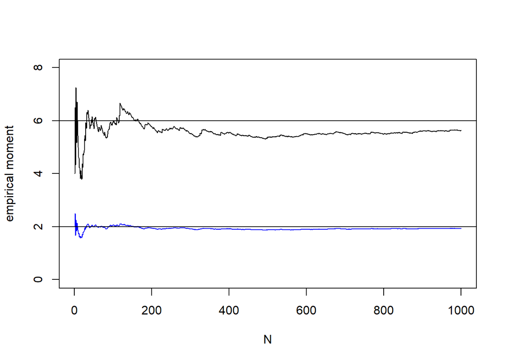

```r
X <- rpois(1000, lambda=2)
N <- 1:1000
mom1 = mom2 = numeric(1000)
for (i in 1:1000) {
  mom1[i] <- mean(X[1:i])
  mom2[i] <- mean(X[1:i]^2)
}
plot(N, mom2, type='l', ylim=c(0,8), ylab='empirical moment')
lines(N, mom1, col='blue')
abline(h=c(2,6))
```

$~$

#### 1.4.0.6 Exercise

Which of the two empirical moments is typically closer to its expectation? Can you give an intuitive explanation for this?

**Click for the answer**

The first moment is closer to its expectation for almost all values of $N$. The explanation for this is that $X^2$ gives extremely large values more often than $X$ itself. Such outliers make the estimate variable and take more time to average out.

$~$

In practice we almost never need more than the first two moments for a method-of-moments estimate. Second moments can be a little bit difficult to work with, so it is usually easier to work with the variance. The variance can be written in terms of moments, as $\mu_2-\mu^2$, so its estimate is $\hat \mu_2 - \hat\mu^2$, which is

$$\hat\sigma^2 = \frac1n\sum_{i=1}^n (X_i - \bar X)^2$$
.

Note the factor $n$ instead of the factor $n-1$ that you may have expected. Tomorrow we learn about the pros and cons of the $n$ or the $n-1$ divisor.

$~$

#### 1.4.0.7 Exercise

Show that $\mathrm{Var}(X) = \mu_2-\mu^2$.

**Click for the answer**

In the usual expression for the variance, we work out the square and simplify all the resulting terms.

$$\begin{align*}
\mathrm{Var}(X) &= \mathrm{E}\big(X - \mathrm{E}(X)\big)^2 \\
&= \mathrm{E}\big(X^2 - 2X\mathrm{E}(X) + (\mathrm{E}(X))^2\big) \\
&= \mathrm{E}(X^2) - 2 \mathrm{E}(X\mathrm{E}(X)) + (\mathrm{E}(X))^2 \\
&= \mathrm{E}(X^2) - 2 \mathrm{E}(X)\mathrm{E}(X) + (\mathrm{E}(X))^2 \\
&= \mathrm{E}(X^2) - (\mathrm{E}(X))^2 \\
&= \mu_2 - \mu^2
\end{align*}$$

If you could not come up with this answer yourself, it is not a problem. In that case, go through all the steps in the answer and explain them. What properties of the expectation are used?

$~$

#### 1.4.0.8 Exercise

Show that $n^{-1}\sum_{i=1}^n (X_i - \bar X)^2 = \hat\mu_2 - \hat\mu^2$.

**Click for the answer**

The calculation is essentially the same as in the previous exercise, although it may look quite different.

$$\begin{align*}
n^{-1}\sum_{i=1}^n (X_i - \bar X)^2 &= n^{-1}\sum_{i=1}^n (X_i^2 -2 X_i \bar X + \bar X^2) \\
&= n^{-1}\sum_{i=1}^n X_i^2 -2 n^{-1}\sum_{i=1}^n \bar X X_i + n^{-1}\sum_{i=1}^n \bar X^2 \\
&= n^{-1}\sum_{i=1}^n X_i^2 -2 \bar X n^{-1}\sum_{i=1}^n X_i + \bar X^2 \\
&= n^{-1}\sum_{i=1}^n X_i^2 -2 \bar X \bar X + \bar X^2 \\
&= n^{-1}\sum_{i=1}^n X_i^2 - \bar X^2 \\
&= \hat\mu_2 - \hat\mu^2
\end{align*}$$

If you could not come up with this answer yourself, it is not a problem. In that case, go through all the steps in the answer and explain them.

$~$

#### 1.4.0.9 Exercise

Suppose $X$ has a Poisson distribution with parameter $\lambda$. For $X=1,3,4,2$, find a method of moments estimate of $\lambda$ using the property that the variance of the Poisson distribution is $\lambda$. Do you think that this is a better estimate than the one based on the mean?

**Click for the answer**

We use $\lambda = \mathrm{Var}(X) \approx \hat\sigma^2$, so $\hat\lambda = \hat\sigma^2$.

```r
# The MOM variance estimate of the data is
X <- c(1,3,4,2)
n <- length(X)
vX <- var(X) * (n-1)/n
# Our method-of-moments estimate for lambda is
vX
```

```
## [1] 1.25
```

Note the $(n-1)/n$ factor when calculating the variance, since R uses $n-1$ by default.

This estimate is probably not as good as the one based on the mean, because, as we’ve seen above, this estimate involves the second moment, which tends to be more variable than the estimate of the mean. We’ll make this intuition more presice in tomorrow’s lecture.

$~$

Let’s have a look at an example with two parameters, for which we really need higher order moments than simply the mean.

Suppose we have observed $X = (0.4, 0.2, -1.1, -0.1, 0.7)$, for which we assume that they come from a normal distribution with unknown mean $\mu$ and variance $\sigma^2$.

The workflow is similar to the one-parameter case, only now we use expressions for both the mean and the variance. Our distribution has mean $\mu$ and variance $\sigma^2$. To estimate these parameters, we plug in the data mean $\bar X$ for $\mu$ and $\hat\sigma^2$ for $\sigma^2$:

$$\mu = \mathrm{E}(X) \approx \bar X \\ \sigma^2 = \mathrm{Var}(X) \approx \hat\sigma^2$$

```r
X = c(0.4, 0.2, -1.1, -0.1, 0.7)
# estimate of mu
mean(X)
```

```
## [1] 0.02
```

```r
# estimate of sigma^2
n = length(X)
var(X) * (n-1) / n
```

```
## [1] 0.3816
```

Sometimes the system of equations is not so simple, but the general workflow for method-of-moments estimation as follows

1. Find the expression of the mean (and/or variance) in terms of the parameters of your distribution.
2. Plug in the sample mean and the method-of-moments estimator for the variance and solve for the parameter(s).

$~$

#### 1.4.0.10 Exercise

Suppose $X = (1.7, 2.0, 3.2, 0.7, 5.4, 1.0)$ are observed from a gamma-distribution with parameters $\alpha$ and $\beta$. We can look up the gamma distribution and find that $\mathrm{E}(X) = \alpha/\beta$ and $\mathrm{Var}(X) = \alpha/\beta^2$. Find method-of-moments estimators for $\alpha$ and $\beta$.

**Click for the answer**

We write down the two equations
$$\bar X = \alpha/\beta \\ \hat\sigma^2 = \alpha/\beta^2.$$

Solving the first equation for $\alpha$, we get first $\alpha = \beta \bar X$. Plugging into he second gives $\hat\sigma^2 = \beta\bar X/\beta^2 = \bar X/\beta$, so $\beta = \bar X/\hat\sigma^2$. Plugging this into the first equation again, we get $\alpha = \bar X^2/\hat\sigma^2$. In summary:

$$\alpha = \bar X^2/\hat\sigma^2 \\ \beta = \bar X/\hat\sigma^2.$$

Now we calculate $\bar X$ and $\hat\sigma^2$ from the data and plug them in.

```r
    X <- c(1.7, 2.0, 3.2, 0.7, 5.4, 1.0)
    n <- length(X)
    mean <- mean(X)
    hatsigma2 <- var(X) * (n-1)/n
    mean^2/hatsigma2    # alpha
```

```
  ## [1] 2.161447
```

```r
    mean/hatsigma2      # beta
```

```
  ## [1] 0.9263344
```

$~$

#### 1.4.0.11 Exercise

We have observed $X = (0.40, 0.23, 1.83, 2.24, 1.61)$, which we assume to have come from a lognormal distribution with parameters $\nu$ and $\tau^2$, with $\tau^2=1$ known. For the lognormal distribution, the expectation is $\exp(\nu + \tau^2/2)$. Find a method-of-moments estimator based on this expression.

**Click for the answer**

We write down the equation $\bar X = \exp(\nu + \tau^2/2) = \exp(\nu + 1/2)$. Solve for $\nu$: $\log \bar X = \nu + 1/2$, so $\nu = \log \bar X - 1/2$.

Now we can calculate $\bar X$ from the data and plug it in.

```r
    X = c(0.40, 0.23, 1.83, 2.24, 1.61)
    mean <- mean(X)
    log(mean) - 0.5  # our estimate of nu
```

```
  ## [1] -0.2673022
```

$~$

Note: the parameters of the lognormal distribution are normally called $\mu$ and $\sigma^2$, but we have renamed them to avoid confusion with the mean and variance.

There is often not one way to make method-of-moments estimators for parameters. In the lecture tomorrow we will learn how to find out whether one estimator is better than another.

Let us give some examples of alternative estimators.

$~$

#### 1.4.0.12 Exercise

We have again observed $X = (0.40, 0.23, 1.83, 2.24, 1.61)$, which we assume to have come from a lognormal distribution with parameters $\nu$ and $\tau^2$, with $\tau^2=1$ known. The variance of a lognormal distribution is $(\exp(\tau^2)-1)\exp(2\nu+\tau^2)$. Derive a method-of-moments estimate for $\nu$ based on this expression.

**Click for the answer**

We write down the equation $\hat\sigma^2 = (\exp(\tau^2)-1)\exp(2\nu+\tau^2) = (\exp(1)-1)\exp(2\nu + 1)$. Solve for $\nu$ by taking the log: $\log \hat\sigma^2 = \log(\exp(1)-1) + 2\nu + 1$, so $2\nu = \log \hat\sigma^2 - \log(\exp(1)-1) - 1$.

Now we can calculate $\hat\sigma^2$ from the data and plug it in.

```r
    X = c(0.40, 0.23, 1.83, 2.24, 1.61)
    n <- length(X)
    hatsigma2 <- var(X) * (n-1)/n
    0.5 * (log(hatsigma2) - log(exp(1)-1) - 1)  # our estimate of nu
```

```
  ## [1] -0.9925139
```

$~$

#### 1.4.0.13 Exercise

You may have noticed that the two estimates for the mean of the lognormal distribution we very different. Can you give an intuituve reason why?

**Click for the answer**

Since there are very few data points, both estimates are likely to be far from the truth. The two estimators use very different summaries of the data (mean or variance) so they vary from the truth in a different way. In summary, they vary from the truth a lot, and each in their own way, so we expect them to be far apart.

$~$

#### 1.4.0.14 Exercise

Suppose, again, that $X$ is log-normally distributed with paramaters $\nu$ and $\tau^2$. We have observed $X = (0.40, 0.23, 1.83, 2.24, 1.61)$. It is a property of the lognormal distribution that if $X$ is log-normally distributed with parameters $\nu$ and $\tau^2$, then $Y = \log(X)$ is normally distributed with parameters $\mu=\nu$ and $\sigma^2=\tau^2$.

- Transform $X$ to $Y$ and formulate a parametric model for $Y$.
- Find a method-of-moments estimator for $\mu=\nu$.

**Click for the answer**

We transform the data.

```r
    X = c(0.40, 0.23, 1.83, 2.24, 1.61)
    Y <- log(X)
```

Our parametric model for $Y$ is that they are nomally distributed with parameter $\mu=\nu$ unknown and $\sigma^2=\tau^2=1$.

We have already found the method-of-moments estimator for the mean of a normal distribution

```r
    mean(Y)
```

```
  ## [1] -0.09978814
```

This is another estimator for $\nu$! In the lecture tomorrow we will discuss ways to find out when one estimator is better than another.

## 1.5 Variability of estimators: the sampling distribution

Estimation is trying to conclude from the data what distribution generated the data. Often, we will do quite a good job, especially if we have a lot of data. However, we will never get it exactly right.

Let’s generate some data from a probability distribution we choose ourselves, so that we know what the true probability distribution is. When a statistician generates data in this way, it is called *simulated data*.

```r
X <- rbinom(10, size=1, prob=0.42)
mean(X)
```

```
## [1] 0.5
```

We didn’t get the probability of success exactly right.

$~$

#### 1.5.0.1 Exercise

It is even impossible with this simulated data to get the probability exactly right. Why?

**Click for the answer**

The estimate is always a multiple of 0.1, so it can never be 0.42.

$~$

#### 1.5.0.2 Exercise

Simulate data a couple of times to see the estimate vary. Now change the sample size to 100. What changes?

**Click for the answer**

Running this a couple of times, we see that the second estimate is often closer to the true value of 0.42 than the first one.

```r
  X <- rbinom(10, size=1, prob=0.42)
  mean(X)
```

```
  ## [1] 0.5
```

```r
  X <- rbinom(100, size=1, prob=0.42)
  mean(X)
```

```
  ## [1] 0.45
```

$~$

The value of a (good) estimator varies around the true value of the parameter. It is sometimes too large and sometimes too small. What values does the estimate take? We can think of taking simulated data many times and recording the value of the estimate. This is called a Monte Carlo *simulation* after the famous casino. We can use a “for”-loop to do the same thing many times:

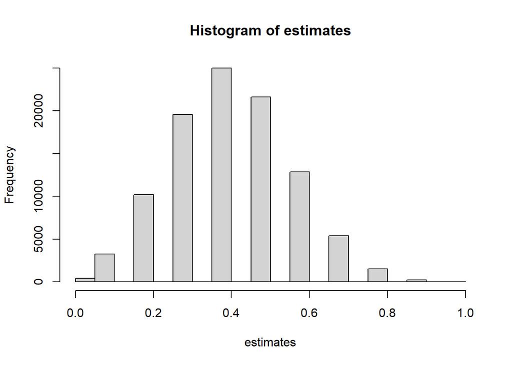

```r
estimates=numeric(1e5)               # make an empty numerical vector of length 10,000
for (i in 1:1e5){
  X <- rbinom(10, size=1, prob=0.42) # sample from the binomial distribution
  estimates[i]=mean(X)               # compute the sample proportion
}
hist(estimates)                      # make a histogram
```

We can do the same thing using the R function `replicate`. There is no need to start with an empty vector:

```r
estimates <- replicate(1e5,
{
  X <- rbinom(10, size=1, prob=0.42)
  mean(X)
})
hist(estimates)
```

We will use for-loops and `replicate` interchangeably. You may use whichever you prefer.

The distribution we have just drawn is the *sampling distribution*. It is the distribution of the estimate of $p$ upon repeating the experiment, when the true value of $p$ is 0.42. An estimate is a function of the data. Since the data are random, so is the estimate: each estimate is the outcome of a random variable, which we call the *estimator*.

The sampling distribution is a very important concept in statistics, because it describes the variability of our estimator around the true value, and therefore the uncertainty of our conclusions from the data. For example, from the sampling distribution we see that with a sample size of 10 it is very common to get an estimate that is at least 0.20 larger or smaller than the true value. Our estimate based on such data is clearly not very reliable!

The sampling distribution depends very much on the sample size.

$~$

#### 1.5.0.3 Exercise

Calculate the sampling distribution for the same estimator if the sample size is 10 and if the sample size is 100, and the true probability of success is 0.31. What is the probability that the estimator is larger than 0.40 in both cases?

**Click for the answer**

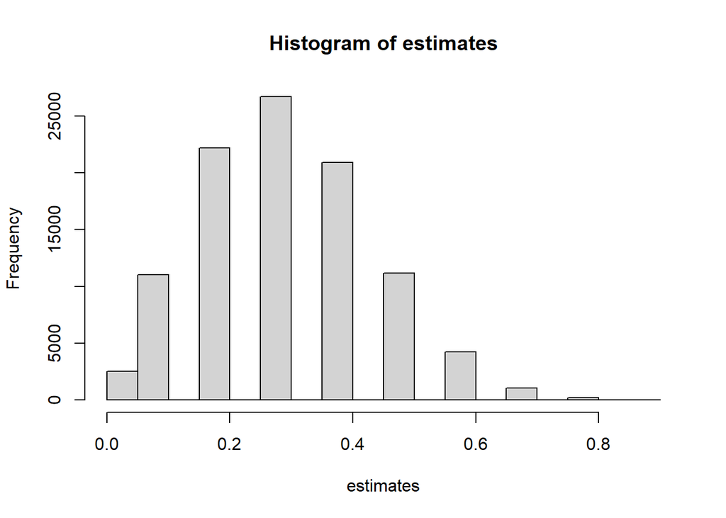

```r
estimates <- replicate(1e5,
{
  X <- rbinom(10, size=1, prob=0.31)
  mean(X)
})
hist(estimates)
```

```r
mean(estimates > 0.4)
```

```
## [1] 0.16667
```

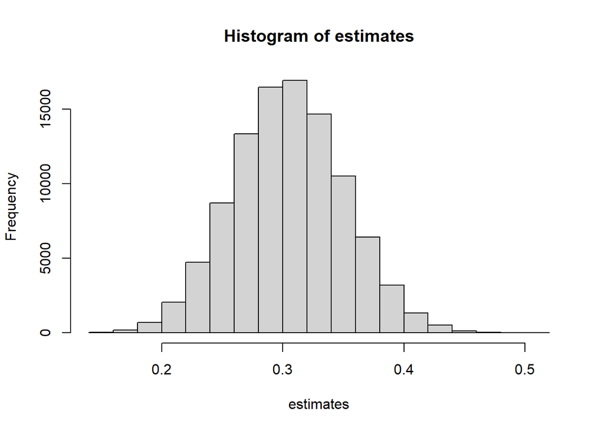

```r
estimates <- replicate(1e5,
{
  X <- rbinom(100, size=1, prob=0.31)
  mean(X)
})
hist(estimates)
```

```r
mean(estimates > 0.4)
```

```
## [1] 0.02043
```

$~$

It is important to realize that, while we often think of estimating as finding one or more parameters, we are essentially always estimating the probability distribution of the data.

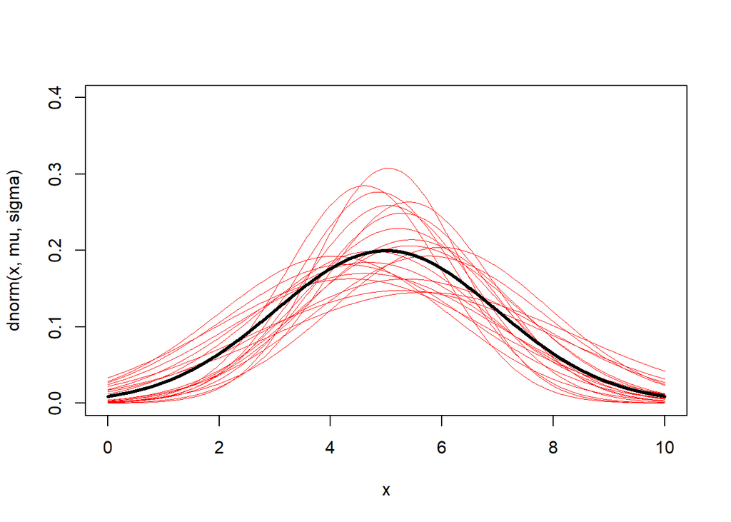

```r
mu <- 5     # true mu
sigma <- 2  # true sigma
x <- seq(0, 10, 0.01)
# true distribution
plot(x, dnorm(x, mu, sigma), type='l', ylim=c(0,.4), lwd=3)

estimates <- replicate(20,
{
  X <- rnorm(10, mu, sigma) # data
  hat.mu <- mean(X)         # estimated mu
  hat.sig <- sd(X)          # estimated sigma
  # estimated distributions
  lines(x, dnorm(x, hat.mu, hat.sig), col="red", lwd=0.5)
})
lines(x, dnorm(x, mu, sigma), lwd=3)
```

## 1.6 What have we learned?

- We can explain the goal of statistics in terms of sample and population.
- We can propose and motivate statistical models for data.
- We can calculate method-of-moments estimators for model parameters.
- We can calculate and explain sampling distributions for estimators.

## 1.7 Appendix: Some probability theory

*Any* sequence $p_0,p_1,p_2,\dots$ can represent a discrete probability distribution if

1. $p_i \geq 0$ for all $i=0,1,2,\dots$
2. $\sum_{k=1}^\infty p_i = 1.$

$~$ If we write $P(X=x_i)=p_i$ then (cumulative) distribution function (CDF) of the random variable $X$ is defined as
$$F(x) = P(X \leq x) = \sum_{i: x_i \leq x} p_i.$$
The cumulative distribution function increases from 0 to 1.

$~$ The expectation and variance of a discrete random variable $X$ are define as
$$EX = \sum_i p_i x_i \qquad\text{and}\quad {\rm Var}(X)=E((X - EX)^2) = \sum_i p_i (x_i-EX)^2$$

$~$ *Any* function $f$ can represent a continuous probability distribution if

1. $f(x) \geq 0,\ {\rm for\ all\ }x$
2. $\int_{x=-\infty}^\infty f(x) dx = 1.$

If a random variable $X$ has *density function* $f$ then
$$P(a < X \leq b) = \int_a^b f(x)dx.$$
The (cumulative) distribution function is defined as
$$F(x) = P(X \leq x) = \int_{-\infty}^x f(y) dy.$$
The cumulative distribution function increases from 0 to 1.

The expectation and variance of a continuous random variable $X$ are define as
$$EX = \int x f(x) dx \qquad\text{and}\quad {\rm Var}(X)=E((X - EX)^2) = \int (x-EX)^2 f(x) dx.$$

$~$ Suppose $X$ and $Y$ are random variables and $a$ and $b$ are scalars (constants, numbers).
$$\begin{align*}
E(aX+b) &=aE(X) + b \\
E(X+Y)&=E(X)+E(Y)\\
{\rm Var}(X) &= E(X^2) - E(X)^2 \\
{\rm Var}(aX+b) &= a^2 {\rm Var}(X) \\
{\rm Var}(X+Y) &= {\rm Var}(X) + {\rm Var}(Y) + 2{\rm Cov}(X,Y)
\end{align*}$$

$~$ It is clear that there are infinitely many probability distributions. A number of important ones are listed on [Wikipedia](http://en.wikipedia.org/wiki/List_of_probability_distributions)

A few distributions that you should definitely *know* are listed below. They are all available in R with names like `binom`, `geom` and `pois`. Before this name you need to add 1 of the following 4 letters.

- d for ``density’’. This is the probability density
- p for ``probability’’. This is the cumulative distribution.
- q for ``quantile’’. This is the quantile function
- r for ``random’’. This is to sample from the distribution.

### 1.7.1 Binomial or `dbinom`

$~$ model: number of successes in $n$ trials with probability of success $p$.

$~$ parameters: $n$ and $p$.

$$P(X=k) = {n \choose k} p^k (1-p)^{n-k},\quad k=1,2,\dots,n.$$

$$EX=np \quad{\rm en}\quad {\rm var}(X)=np(1-p)$$

$~$ Given $X$ successes in $n$ trials, we can estimate $p$ as

$$\hat p = \frac{X}{n}.$$

$~$ The Binomial distribution with parameters $n=1$ and $p$ is sometimes called the Bernoulli distribution with parameter $p$.

### 1.7.2 Geometric or `dgeom`

$~$ model: number of trials until first success when the probability of success is $p$.

$~$ parameter: $p$

$$P(X=k) = (1-p)^{k-1} p,\quad k=1,2,3,...$$

$$EX=\frac1p \quad{\rm en}\quad {\rm var}(X)=\frac{1-p}{p^2}$$

$~$ Estimate based on iid sample $X_1,X_2,\dots,X_n$

$$\hat p = \frac{1}{\bar X}.$$

### 1.7.3 Poisson or `dpois`

$~$ model: number of calls at call center per unit time.

$~$ parameters: $\lambda$

$$P(X=k) = \frac{\lambda^k}{k!} e^{-\lambda},\quad k=0,1,2,...$$

$$EX=\lambda \quad {\rm en}\quad {\rm var}(X)=\lambda$$

$~$ Estimate based on iid sample $X_1,X_2,\dots,X_n$

$$\hat \lambda = \bar X.$$

### 1.7.4 Uniform or `dunif`

$~$ model: random number in interval.

$~$ parameters: the bounds of the interval: $[a,b]$

$$f(x) = \frac{1}{b-a},\quad x \in [a,b]$$

$$EX=\frac{a+b}{2} \quad {\rm and}\quad {\rm var}(X)=\frac{(b-a)^2}{12}$$

$~$ Estimate based on iid sample $X_1,X_2,\dots,X_n$

$$\hat a = \min(X_1,X_2,\dots,X_n)\quad{\rm en}\quad \hat b = \max(X_1,X_2,\dots,X_n).$$

### 1.7.5 Exponential or `dexp`

$~$ model: life time (of a transistor)

$~$ parameters: $\lambda > 0$

$$f(x) = \lambda e^{-\lambda x},\quad x>0$$

$$EX=\frac{1}{\lambda} \quad {\rm en}\quad {\rm var}(X)=\frac{1}{\lambda^2}$$

$~$ Estimate based on iid sample $X_1,X_2,\dots,X_n$

$$\hat \lambda = \frac{1}{\bar X}$$

### 1.7.6 Normal (Gaussian) or `dnorm`

model: distribution of measurement error

$~$ parameters: $\mu$ en $\sigma^2$

$$f(x) = \frac{1}{\sqrt{2\pi}\sigma} e^{-(x-\mu)^2/2\sigma^2}.$$

$$EX=\mu \quad {\rm en}\quad {\rm var}(X)=\sigma^2$$

$~$ Estimate based on iid sample $X_1,X_2,\dots,X_n$

$$\hat \mu = \bar X \quad {\rm en}\quad S^2 = \frac{1}{n-1} \sum_i (X_i - \bar X)^2.$$

The maximum likelihood estimate of the variance is
$$\hat \sigma^2 = \frac{1}{n} \sum_i (X_i - \bar X)^2.$$

### 1.7.7 Student $t$ or `dt`

model: If $X_1,X_2,\dots,X_n$ are an iid sample from the normal distribution with mean $\mu$ and variance $\sigma^2$ then
$$T = \sqrt{n} \frac{\bar X - \mu}{S}$$
has the $t$ distribution with $n-1$ degrees of freedom.

$~$ parameters: degrees of freedom $n-1$

$$EX=0 \quad {\rm en}\quad {\rm var}(X)=\frac{n-1}{n-3}\quad n>3$$

### 1.7.8 Chi-squared ($\chi^2$) or `dchisq`

model: If $X_1,X_2,\dots,X_n$ are an iid sample from the standard normal distribution (with mean 0 and variance 1) then

$$Q = \sum_{i=1}^n X_i^2$$
has the $\chi^2$ distribution with $n$ degrees of freedom.

$~$ parameters: degrees of freedom $n$

$$EX=n \quad {\rm en}\quad {\rm var}(X)=2n$$

# 2 Bias and Mean Squared Error

## 2.1 Good and bad estimators

In the previous chapter we introduced the concept of estimation. The goal is to find a probability distribution from a set of candidate distributions (or “model”) that best fits the observed data. We discussed the method of moments where we find the estimate by matching the moments (mean, variance, skewness,…) to the observed sample moments.

The method of moments is just one of many approaches. Here, we start by pointing out that there are typically many estimators, some of which are good and some which are not so good. Consider the following example.

Suppose we observed the number of calls to some call center during 20 consecutive weekdays, and let’s denote those numbers by $X_1,\dots,X_{20}$. An obvious model for these data is to imagine that it is an i.i.d. sample of size 20 from some Poisson distribution. Poisson distributions are characterized by just one parameter, its mean (or expected value) which we denote by $\lambda$. Now recall the special fact about Poisson distributions that the mean equals the variance. So then we have two obvious estimators for $\lambda$, namely the sample average and the sample variance.

$~$

#### 2.1.0.1 Exercise

Which do you think is a better estimator of $\lambda$? The sample average or the sample variance? How would you decide? What does it even *mean* for an estimator to be better than another?

**Click for the answer**

Estimators can be bad because the have large systematic “bias” which means that they tend to over- or underestimate. They can *also* be bad because the are very variable. We will discuss these problems below.

$~$

To decide which is better, let’s just try it out. We choose some arbitrary value for $\lambda$, for example $\lambda=5$, and generate a sample of size 20. Now we can compute our two estimators and check which is closer to 5! Now of course, trying this only one time does not tell us much. But if we try it 10,000 times, we should get a good sense which is better. Carefully check the following code:

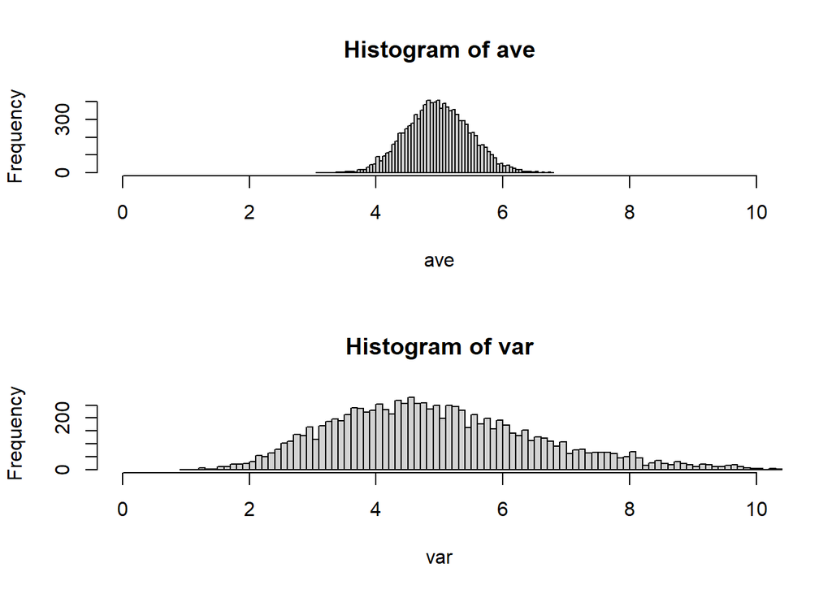

```r
k=10000
ave=var=numeric(k)
for (i in 1:k){
  x=rpois(n=20,lambda=5)  # data
  ave[i]=mean(x)          # sample average
  var[i]=var(x)           # sample variance
}
par(mfrow=c(2,1))
hist(ave,100,xlim=c(0,10))
hist(var,100,xlim=c(0,10))
```

These histograms show the *sampling distribution* of the two estimators.

$~$

#### 2.1.0.2 Exercise

Now which do you think is a better estimator of $\lambda$? The sample average or the sample variance?

**Click for the answer**

Both sampling distributions are centered around the true value of lambda (in this case: 5) so there is no (or at least, not much) systematic bias. But the average is much less variable (it’s more stable) than the sample variance.

$~$

There are two very important things to notice about the histograms (sampling distributions):

1. Both sampling distributions are centered around the true value of $\lambda$ (in this case: 5). We say that both estimators are *unbiased*.
2. The sample average is much less variable than the sample variance. The standard deviation of an estimator is usually called the *standard error*.

It is clear from the histograms that the sample average is typically much closer to the true value of $\lambda$ than the sample variance. We conclude that the sample average is a much better estimator of $\lambda$ than the sample variance!

$~$

#### 2.1.0.3 Exercise

Strictly speaking, we only know now that the sample average is a much better estimator of $\lambda$ than the sample variance when $n=20$ and $\lambda=5$. It is quite possible that that’s not true for other values of $n$ and $\lambda$. Make similar histograms as above but for different values of $n$ and $\lambda$. What do you conclude?

**Click for the answer**

It holds generally that while both estimators are unbiased, the average is more stable.

$~$

We will consider a few more examples. Suppose we have a sample of size $n=15$ from a normal distribution with unknown mean $\mu$ and standard deviation $\sigma$. We can estimate $\mu$ by the sample average but also by the sample median. Which is better?

$~$

#### 2.1.0.4 Exercise

Investigate if the sample average or the sample median is better. Use the approach we just applied to the Poisson distribution.

**Click for the answer**

Just choose some values for mu and sigma, say mu=3 and sigma=1

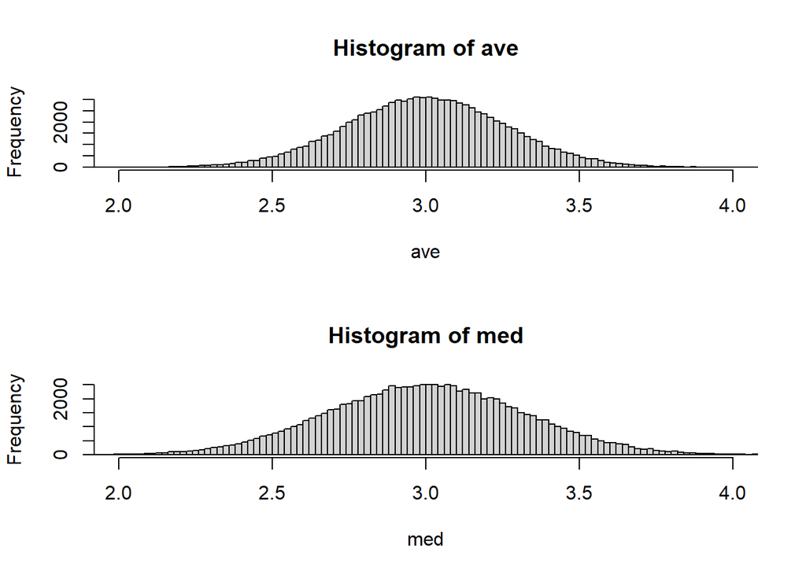

```r
k=10^5
ave=med=numeric(k)
for (i in 1:k){
  x=rnorm(n=15,mean=3,sd=1)  # data
  ave[i]=mean(x)             # sample average
  med[i]=median(x)           # sample median
}
par(mfrow=c(2,1))
hist(ave,100,xlim=c(2,4))
hist(med,100,xlim=c(2,4))
```

```r
mean(ave)
```

```
## [1] 2.999999
```

```r
sd(ave)   # standard error of the sample average
```

```
## [1] 0.2583265
```

```r
mean(med)
```

```
## [1] 3.000709
```

```r
sd(med)   # standard error of the sample median
```

```
## [1] 0.3192969
```

By checking the mean and standard error of the two estimators, we see that they are both unbiased, but the median is more variable than the average. So the average is the better estimator. Using different values for mu and sigma is just a matter of shifting and scaling the sampling distributions, and has no influence on the comparison.

$~$

## 2.2 Bias, variance and the mean squared error

If an estimator is not systematically too large or too small, it is called *unbiased*. Formally, the bias of an estimator $T$ of a parameter $\theta$ is defined as difference between the expecation of the estimator and the parameter
$${\rm bias}(T) = \mathbb{E}(T) - \theta.$$
An estimator is *unbiased* if the bias is zero. Unbiasedness – or at least having small bias – is of course a good thing.

Let’s consider an example. Suppose we have an i.i.d. sample of size $n$ from some normal distribution. The method of moments estimator of the variance $\sigma^2$ is
$$\hat \sigma^2 = \frac1n \sum_{i=1}^n X_i^2 - \left( \frac1n \sum_{i=1}^n X_i \right)^2 = \frac1n \sum_{i=1}^n (X_i - \bar X)^2.$$

$~$

#### 2.2.0.1 Exercise

Verify numerically that this estimator is biased; it is systematically too small. Choose a sample of size $n=6$ from the normal distribution with $\mu=0$ and $\sigma^2=4$. Then check mean of the sampling distribution

**Click for the answer**

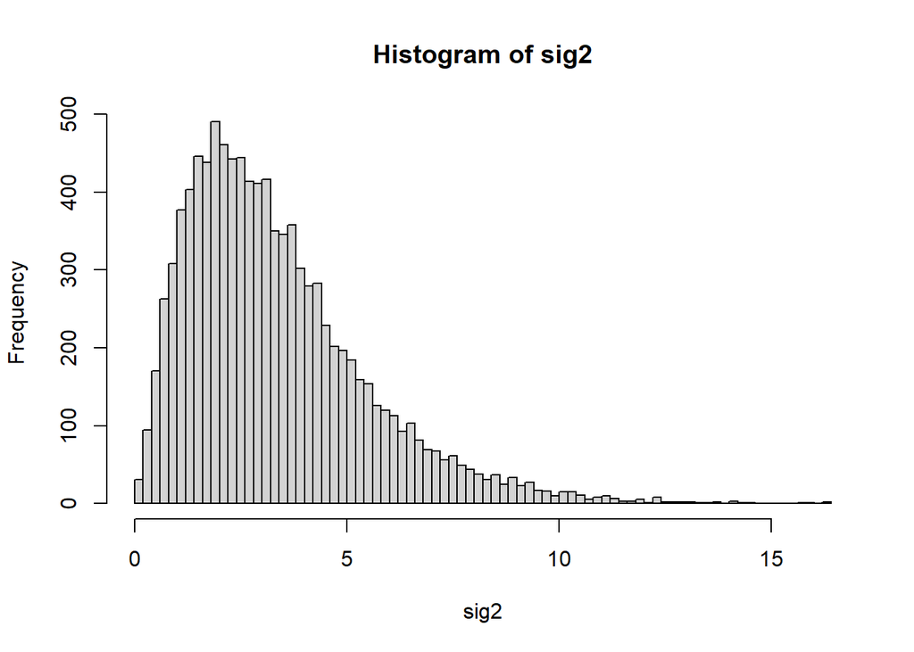

```r
k=10000
sig2=numeric(k)
for (i in 1:k){
  x=rnorm(n=6,mean=0,sd=2)      # data
  sig2[i]=sum((x-mean(x))^2)/6
}
hist(sig2,100)
```

```r
mean(sig2)
```

```
## [1] 3.334865
```

The estimator $\hat \sigma^2$ is less than 4 on average; it’s biased. It’s too small by about a factor 5/6.

$~$

The sample variance is usually defined by dividing by $(n-1)$ instead of $n$. This is also what the ${\tt R}$ function ${\tt var}$ does.
$$S^2 = \frac{1}{n-1} \sum_{i=1}^n (X_i - \bar X)^2.$$

$~$

#### 2.2.0.2 Exercise

Verify numerically that $S^2$ is an unbiased estimator of the variance. Choose a sample of size $n=6$ from the normal distribution with $\mu=0$ and $\sigma=2$. Then check the mean of the sampling distribution.

**Click for the answer**

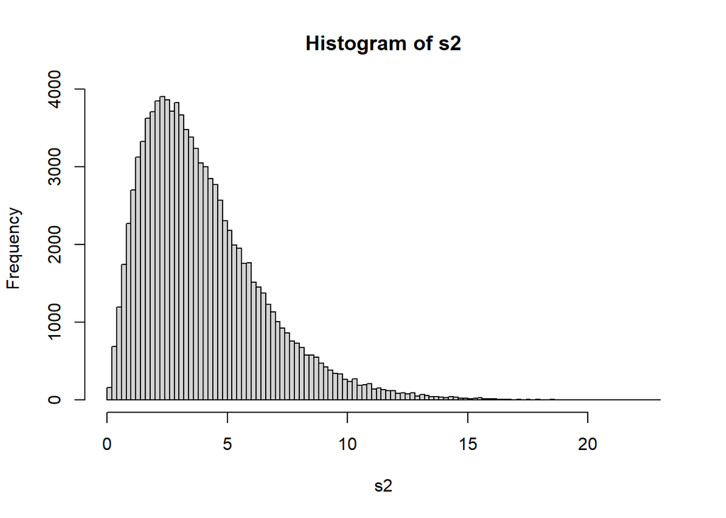

```r
k=10^5
s2=numeric(k)
for (i in 1:k){
  x=rnorm(n=6,mean=0,sd=2)  # data
  s2[i]=sum((x-mean(x))^2)/(6-1)
}
hist(s2,100)
```

```r
mean(s2)     # The estimator s2 is unbiased.
```

```
## [1] 3.982476
```

$~$

#### 2.2.0.3 Exercise

Suppose we have an i.i.d. sample $X_1,X_2,X_3$ from a normal distribution with mean $\mu$ and variance $\sigma^2$.

1. Consider estimators of $\mu$ of the form $w_1X_1 + w_2X_2 + w_2X_2$ with “weights” $w_1,w_2$ and $w_3$. How should you choose these weights to get an unbiased estimator?
2. Unbiasedness is not the only good property of an estimator. Small variance is also important! How would you choose the weights to have not only unbiasedness, but also a small variance?

**Click for the answer**

1. The estimator is unbiased if (and only if) $w_1+w_2+w_3=1$, because
   $$E(w_1X_1 + w_2X_2 + w_2X_2) = w_1 \mu + w_2 \mu + w_3\mu = (w_1+w_2+w_3) \mu$$
2. The estimator is unbiased *and* has the smallest variance if $w_1=w_2=w_3=1/3$. The variance of the estimator is $(w_1^2+w_2^2+w_3^2)\sigma^2$. We can use the so-called Lagrange multiplier to minimize $(w_1^2+w_2^2+w_3^2)$ subject to the constraint $w_1+w_2+w_3=1$. But it’s also “obvious” that each observation should contribute equally.

$~$

Unbiasedness is nice, but it isn’t everything! A slightly biased estimator that is very stable can be better than an unbiased estimator that is more variable. To decide which estimator is best, it is often useful to consider the *mean squared error* or MSE. That is, we check on average how far an estimator is from the target parameter. We use the squared difference so that positive and negative error do not cancel each other out. Formally, the MSE of an estimator $T$ of a parameter $\theta$ is defined as
$${\rm MSE}(T) = \mathbb{E}((T-\theta)^2)$$

Now let us compare the mean squared error of our two estimators of the variance.

```r
k=10^5
sig2=s2=numeric(k)
for (i in 1:k){
  x=rnorm(n=6,mean=0,sd=2)  # data
  sig2[i]=sum((x-mean(x))^2)/6
  s2[i]  =sum((x-mean(x))^2)/5
}
mean((sig2-4)^2)   # mean squared error of sig2
```

```
## [1] 4.8859
```

```r
mean((s2-4)^2)     # mean squared error of s2
```

```
## [1] 6.394861
```

We see that the biased estimator $\hat \sigma^2$ has *lower* MSE compared to the unbiased estimator $S^2$. This happens is because $\hat \sigma^2$ makes up for its bias by being less variable than $S^2$. We conclude that $\hat \sigma^2$ is a better estimator of $\sigma^2$ than than $S^2$ – at least in terms of the MSE.

Now when the sample size $n$ is not too small, the difference between $\hat \sigma^2$ and $S^2$ is not very big. For example, if $n=100$ then it really doesn’t matter much if you divide by 100 or 99. So in most applications, it isn’t very important which estimator you use.

$~$

#### 2.2.0.4 Exercise (from Dekking et al)

Suppose the enemy has $N=5000$ tanks with serial numbers $1,2,\dots,5000$. We do not know $N$, but so far we have captured 10 tanks with numbers $X_1,X_2,...,X_{10}$. Commander Bond of the secret service proposed the following estimator of $N$ based on these numbers
$$T_1=2 \bar{X} - 1.$$

An unnamed person in department Q has a different proposal
$$T_2=\frac{11}{10}\max(X_1,X_2,...,X_{10})-1$$

1. Make histograms of the sampling distributions of $T_1$ and $T_2$. Use ${\tt par(mfrow=c(2,1))}$ to align them vertically. You can use the command ${\tt sample(5000,10)}$ to sample 10 out of 5000 without replacement.
2. Both estimators $T_1$ and $T_2$ are unbiased. Computing the mean of their sampling distributions.
3. Which estimator has the smaller mean squared error?

**Click for the answer**

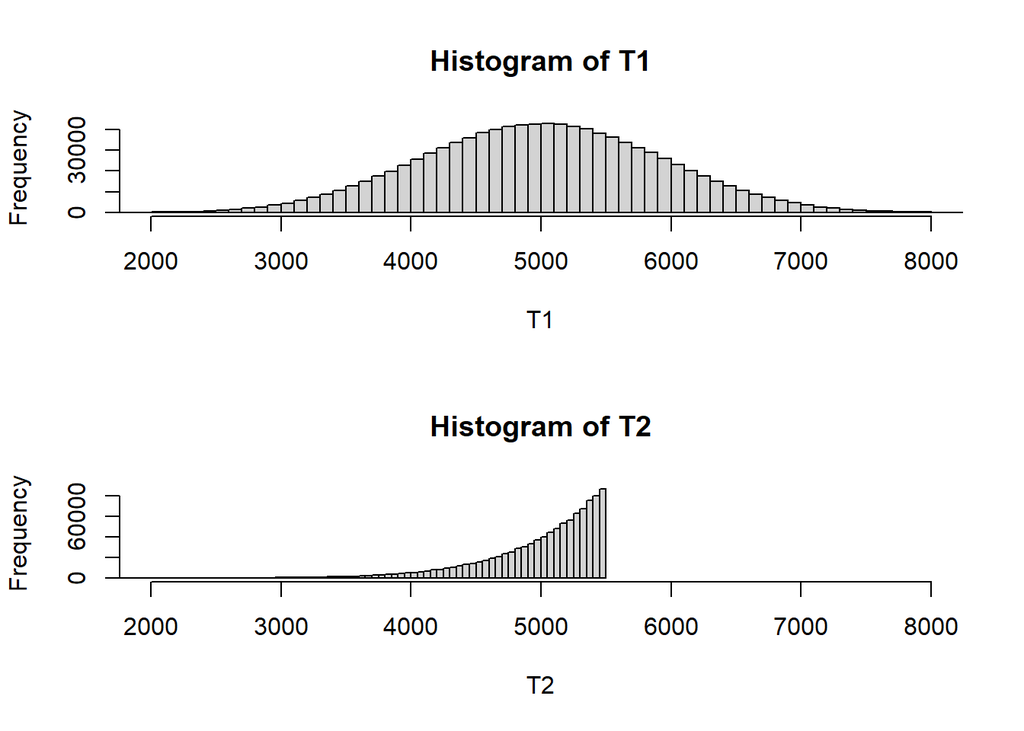

```r
k=10^6
T1=T2=numeric(k)
for (i in 1:k){
   x = sample(5000,10)               # sample 10 from 5000 without replacement
   T1[i] = 2*mean(x)-1               # compute T1
   T2[i] = (11/10)*max(x)-1          # compute T2
}
par(mfrow=c(2,1))
hist(T1,100,xlim=c(2000,8000))
hist(T2,100,xlim=c(2000,8000))
```

```r
mean(T1) - 5000     # bias of T1
```

```
## [1] 1.900991
```

```r
mean((T1-5000)^2)   # mean squared error of T1
```

```
## [1] 831789
```

```r
mean(T2) - 5000     # bias of T2
```

```
## [1] 0.5323963
```

```r
mean((T2-5000)^2)   # mean squared error of T2
```

```
## [1] 207849.8
```

$~$

#### 2.2.0.5 Exercise (from Dekking et al)

Suppose $X_1,X_2,...,X_{20}$ are an i.i.d. sample from the de Poisson distribution with parameter $\lambda=2$. Then the probability of observing no events is
$$P(X=0)=e^{-\lambda}.$$
Suppose we do not know $\lambda$ but we want to estimate the probability of observing no events. There are two obvious estimators
$$T_1=\frac{\# \{X_i = 0\}}{n}\quad {\rm and} \quad T_2=e^{-\bar X}.$$

1. Why are these estimators “obvious”?
2. Make histograms of the sampling distributions of the two estimators, and align them vertically.
3. Check that $T_1$ is unbiased, but $T_2$ is slightly biased.
4. Which estimator has the smaller MSE?

**Click for the answer**

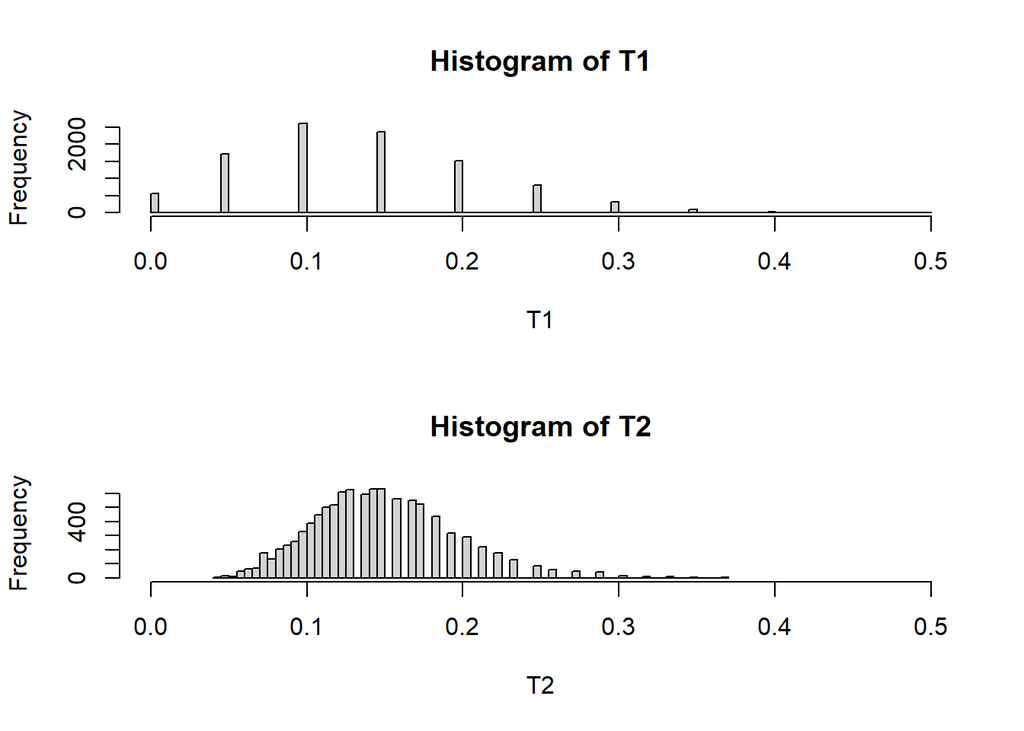

```r
# T1 estimates the probability P(X=0) by the sample proportion
# T2 estimates lambda with the average, and plug the estimator into the formula
# for P(X=0)

# T2 has the smaller MSE

k=10000
T1=T2=numeric(k)
for (i in 1:k){
   x = rpois(n=20,lambda=2)          # sample 20 Poisson(lambda=2)
   T1[i] = mean(x==0)                # compute T1
   T2[i] = exp(-mean(x))             # compute T2
}
par(mfrow=c(2,1))
hist(T1,100,xlim=c(0,0.5))
hist(T2,100,xlim=c(0,0.5))
```

```r
mean(T1) - exp(-2)     # bias of T1
```

```
## [1] -0.001365283
```

```r
mean((T1-exp(-2))^2)   # mean squared error of T1
```

```
## [1] 0.005830903
```

```r
mean(T2) - exp(-2)     # bias of T2
```

```
## [1] 0.0061557
```

```r
mean((T2-exp(-2))^2)   # mean squared error of T2
```

```
## [1] 0.002050543
```

$~$

#### 2.2.0.6 Exercise

Suppose we have an i.i.d. sample $X_1,X_2,\dots,X_n$ from a normal distribution with unknown mean $\mu$ and variance $\sigma$.

1. $(\bar X)^2 = (\frac1n \sum_{i=1}^n X_i )^2$ is not an unbiased estimator of $\mu^2$. Why not?
2. Make an unbiased estimator of $\mu^2$.
3. Use simulation to compare the bias and MSE of the unbiased estimator and $(\bar X)^2$.

**Click for the answer**

1. We know that
   $$\text{Var}(\bar X)=E(\bar{X}^2) - (E \bar X)^2 = E(\bar{X}^2) - \mu^2.$$
   So,
   $$\mu^2 = E(\bar{X}^2) - \text{Var}(\bar X).$$

Since $\text{Var}(\bar X)>0$, it follows that $E(\bar{X}^2) > \mu^2$. So, $(\bar X)^2$ is biased.

2. Clearly, $\bar X^2$ is an unbiased estimator of $E(\bar{X}^2)$. Now, we know that $\text{Var}(\bar X)=\sigma^2/n$. Since
   $$S^2 = \frac{1}{n-1} \sum_{i=1}^n (X_i - \bar X)^2$$
   is an unbiased estimator of $\sigma^2$, it follows that $S^2/n$ is an unbiased estimator of $\text{Var}(\bar X)$. Putting the two together,
   $$\bar X^2 - S^2/n$$
   is unbiased for $\mu^2$.
3. In most cases, the unbiased estimator has smaller MSE. But not always! When the sample size is very small, the estimate of $\sigma$ is so bad that the MSE of the unbiased estimator is larger!

```r
k=10^5
n=2
sig=1
mu=0
t1=t2=numeric(k)
for (i in 1:k){
  x=rnorm(n=n,mean=mu,sd=sig)      # data
  t1[i]=mean(x)^2                  # biased estimator
  t2[i]=mean(x)^2 - var(x)/n       # unbiased estimator
}
mean(t1 - mu^2)   # bias of t1
```

```
## [1] 0.498332
```

```r
mean((t1-mu^2)^2) # mse of t1
```

```
## [1] 0.7442774
```

```r
mean(t2 - mu^2)   # bias of t2
```

```
## [1] -0.003690465
```

```r
mean((t2-mu^2)^2) # mse of t2
```

```
## [1] 0.9944082
```

$~$

There is an interesting way to re-write the mean squared error. Recall that the variance of a random variable $X$ is defined as
$${\rm Var}(X) = \mathbb{E}((X - \mathbb{E}X)^2) = \mathbb{E}X^2 - (\mathbb{E}X)^2$$
So,
$$\mathbb{E}X^2 ={\rm Var}(X) + (\mathbb{E}X)^2.$$
Now, it follows that
$$\begin{align*}
{\rm MSE}(T) &= \mathbb{E}((T-\theta)^2)\\
&= {\rm Var}(T-\theta) + [\mathbb{E}(T-\theta)]^2 \\
&= {\rm Var}(T) + {\rm bias}(T)^2
\end{align*}$$

In other words: the mean squared error of an estimator is the sum of its variance and the square of its bias.

In statistics, there often a trade-off between bias and variance. That is, you can often reduce the variance by increasing the bias (and vice versa). The mean squared error is often a good way to compare estimators because it takes both the bias and the variance into account.

$~$

#### 2.2.0.7 Exercise

Suppose we have an i.i.d. sample of size $n$ from some normal distribution. The method of moments estimator of the variance $\sigma^2$ is $\hat \sigma^2 = \frac1n \sum_{i=1}^n (X_i - \bar X)^2$. We have previously verified numerically that this estimator is biased; it is systematically too small.

Consider a sample of size $n=6$ from the normal distribution with $\mu=0$ and $\sigma^2=4$. Verify numerically that the mean squared error of $\hat \sigma^2$ is indeed the sum of its variance and the square of its bias.

**Click for the answer**

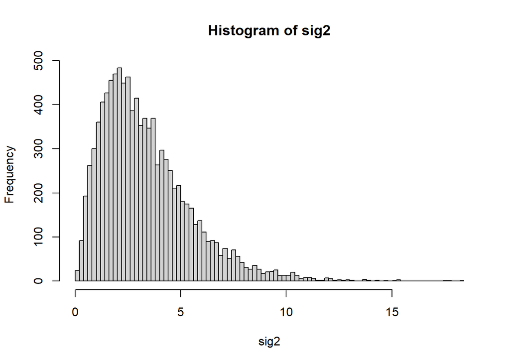

```r
k=10000
sig2=numeric(k)
for (i in 1:k){
  x=rnorm(n=6,mean=0,sd=2)      # data
  sig2[i]=sum((x-mean(x))^2)/6
}
hist(sig2,100)
```

```r
bias=mean(sig2) - 4
variance=var(sig2)
variance + bias^2  # MSE
```

```
## [1] 4.95846
```

```r
mean((sig2-4)^2)   # MSE
```

```
## [1] 4.958007
```

The slight difference comes from the fact that the R function `var` divides by (n-1) instead of n.

$~$

## 2.3 What have we learned

- We know that an estimator is a random variable with a probability (“sampling”) distribution.
- We know what the bias of an estimator is.
- We know that the variance of an estimator is important too.
- We know that the mean squared error (MSE) is a measure of the quality of an estimator that combines the variance and the (squared) bias.

$~$

# 3 Simulation and the Bootstrap

## 3.1 Simulation

In the previous chapter we have “tried things out” by repeated random sampling. A nicer term is “simulation” or sometimes “Monte Carlo simulation”, “Monte Carlo integration” or simply “Monte Carlo” after the famous casino.

Simulation may seem like a cheap trick, but in fact it is *extremely* powerful. First of all, it can replace mathematical ability to a large extent. For example, suppose $X$ has the normal distribution with mean $\mu$ and standard deviation $\sigma$. Now, what is the expected value of the new random variable $Y=e^X$.

That is not an easy question! However, if you are very good with integrals then you would be able to derive that $\mathbb{E}(Y)=e^{\mu + \sigma^2/2}$. So, if $\mu=1$ and $\sigma=1$, then $\mathbb{E}(Y)=e^{1.5}=4.482$.

You could also just forget about integrals and simulate:

```r
x=rnorm(10^6,mean=1,sd=1)
mean(exp(x))
```

```
## [1] 4.484473
```

Easy-peasy, and close enough for most purposes. And if it is not good enough, then just use 10^7 or 10^8. Hopefully you see now that simulation is so simple and so general, that it can be used when even the most clever mathematician has to give up.

$~$

#### 3.1.0.1 Exercise

Look up what is $\mathrm{E}(X)$ when $X$ is Poisson distributed with rate $\lambda=2$. Now calculate the same expectation using simulation. Explain the difference. How could you make the difference smaller?

**Click for the answer**

```r
X = rpois(1e5, lambda = 2)
mean(X)
```

```
## [1] 1.994
```

$~$

We can say that simulation turns a mathematical problem (solving an integral) into a statistical problem (analyzing a sample). Perhaps this is why statisticians like it so much!

## 3.2 The bootstrap

We now turn to the very useful “parametric bootstrap” method, which is based on simulation. Consider the following general set-up. Let $T$ be an estimator of some parameter $\theta$. We are very much interested in the distribution of the random variable $B=T-\theta$. Note
$$\begin{align*}
\mathbb{E}(B) &=\mathbb{E}(T-\theta)={\rm bias}(T) \\ \mathbb{E}(B^2) &=\mathbb{E}((T-\theta)^2)={\rm MSE}(T)
\end{align*}$$
So, the expectation of $B$ is the bias of $T$, and the expectation of $B^2$ is the MSE of $T$. Moreover, the variance of $T$ is equal to the variance of $B$, and the standard error of $T$ is equal to the standard deviation of $B$ (recall that the standard deviation of an estimator is often called the standard “error”).

$~$

#### 3.2.0.1 Exercise

Why is the variance of $T$ equal to the variance of $B$?

**Click for the answer**

Recall the general rule $Var(aX+b)=a^2 Var(X)$. Now take $X=T$, $a=1$ and $b=-\theta$.

$~$

The distribution of $B$ generally depend on $\theta$ which we don’t know. But if we are lucky (and this is often the case), the dependence is not very strong.

For example, suppose we have a sample of size $n$ from a normal distribution with unkown mean, but known standard deviation $\sigma$. We estimate the mean $\mu$ by the average $\bar X$. In this case, $B=\bar X-\mu$. In the previous section, we found that $E(B)=0$ and $E(B^2)=\sigma^2/n$. These quantities do not depend on $\mu$ at all!

Estimating the population mean with the sample average is rather trivial. But for more complicated estimators, it becomes much more difficult to get the bias, standard error and MSE. However, we can often use the bootstrap if we cannot do the math. We will explain how that works with the simple case of estimating the mean of a normal sample.

Suppose we have a sample of size 50 from a normal distribution with unknown $\mu$, but *known* standard deviation $\sigma=5$. We estimate $\mu$ by the sample average $\bar X$ and define $B=\bar X - \mu$. The bias of $\bar X$ is zero and the MSE is $\sigma^2/n=5^2/50=0.5$. The standard error of $\bar X$ is $\sqrt{0.5}=0.71$.

The idea of the bootstrap is very simple. First, we estimate the distribution of the data and then we simulate from *that* distribution to obtain the distribution of $B=\bar X - \mu$. Replacing the true parameter (which we don’t know) by the estimate (which we have) is called *plug-in*.

> **Plug-in Principle**

> If $\hat\theta$ is a good estimator of $\theta$, then we may plug in $\hat\theta$ for $\theta$ when calculating its bias and variance

Note that there is an apparent circularity in the use of this principle: we try to estimate the uncertainty of the estimator using the uncertain estimator itself. This is why it is called the bootstrap, from the famous story, sometimes attributed of the Baron von Münchhausen, who pulls himself from the swamp by his own bootstraps (or his own hair, accounts differ)

[figure not shown]

We will now make some data, where we set the “seed” of the random number generator so that everyone will get the same set of numbers. Remember: we are pretending that we don’t know $\mu$, but we do know that $\sigma=5$.

```r
set.seed(123)
x=rnorm(n=50,mean=10,sd=5)       # these are our data. we know sigma=5
                                 # but we do not know that mu=10.
```

Of course, we estimate $\mu$ by the sample average. We are interested in the bias, MSE, variance and standard error of the sample average. We can use mathematics to compute those, but we can also do the bootstrap instead:

```r
xbar=mean(x)                     # we estimate mu by xbar

# Now use the parametric bootstrap
# we simulate from the *estimated* distribution:
k=10000
B=numeric(k)
for (i in 1:k){
  x.boot=rnorm(n=50,mean=xbar,sd=5)  # simulate from the **estimated** distribution
  xbar.boot=mean(x.boot)
  B[i]=xbar.boot - xbar              # now we know the true mean; it's xbar!
}
mean(B)                    # bootstrapped bias, should be about zero
```

```
## [1] 0.0002893407
```

```r
mean(B^2)                  # bootstrapped MSE, should be about 0.5
```

```
## [1] 0.4840577
```

```r
var(B)                     # bootstrapped variance of Xbar, should be about 0.5
```

```
## [1] 0.484106
```

```r
sd(B)                      # bootstrapped standard error of Xbar, should be about 0.71
```

```
## [1] 0.6957772
```

$~$

#### 3.2.0.2 Exercise

Read this crucial script and make sure you understand every line. In paticular, notice how we *do* know the true mean of the simulated data!

**Click for the answer**

```r
# Ask the TA or the instructor if there's something you don't understand.
```

$~$

**Remark 1** Without the math of the previous section, we have managed to do the computions – approximately, at least. So the bootstrap is very powerful, but it is also very dangerous. On the one hand, it’s so simple that a child can do it. On the other hand, you need much understanding and experience to know what you’re doing and when it might not work!

**Remark 2** It is important to note that the bootstrap only provides an *approximate* answer; the MSE is actually 0.5, but we got 0.48. This is something you might feel uncomfortable with, but it happens very often in statistics. There are typically many ways to do roughly the same thing, and they all give slightly different answers. Of course, you have to realize that a difference in the second decimal is *nothing* compared to the uncertainty that we get from the fact that our assumptions are never true. Real data are never exactly independent, or exactly normally distributed, or whatever else we might assume. The trick is to not worry about little mistakes, while making sure you avoid the big ones! That does take some practice.

The bootstrap is a combination of two approximations

1. Plug-in: data are distributed with true parameter $\theta$, but we plug in $\hat\theta$ instead
2. Simulation: Bias $\mathrm{E}(\hat\theta - \theta)$ and variance $\mathrm{Var}(\hat\theta)$ are calculated by Monte Carlo integration

Both plug-in and Monte Carlo are important statistical tools that we will encounter many times more!

$~$

#### 3.2.0.3 Exercise

Adjust the bootstrap script to handle the case when you do *not* know $\sigma$, and therefore have to estimate it.

**Click for the answer**

```r
set.seed(123)
x=rnorm(n=50,mean=10,sd=5)       # these are our data. we do not that sigma=5
                                 # and we do not know that mu=10.

xbar=mean(x)                     # we estimate mu by xbar
s=sd(x)                          # we estimate sigma by the sample standard deviation
```

We know that the average is unbiased. The MSE is therefore equal to the variance of Xbar, which is $sigma^2/n$. Since we don’t know what sigma is, we can now only estimate the MSE

```r
s^2/50  # estimated MSE is about 0.43
```

```
## [1] 0.4286176
```

Now use the parametric bootstrap; we simulate from the *estimated* distribution:

```r
k=10000
B=numeric(k)
for (i in 1:k){
  x.boot=rnorm(n=50,mean=xbar,sd=s)  # simulate from the estimated distribution
  xbar.boot=mean(x.boot)
  B[i]=xbar.boot - xbar             # now we know the true mean; it's xbar!
}
mean(B)                    # bootstrapped bias, should be about zero
```

```
## [1] 0.0002678918
```

```r
mean(B^2)                  # bootstrapped MSE, should be about 0.43
```

```
## [1] 0.4149513
```

```r
var(B)                     # bootstrapped variance of Xbar, should be about 0.43
```

```
## [1] 0.4149927
```

```r
sd(B)                      # bootstrapped standard error of Xbar, should be about 0.66
```

```
## [1] 0.6441993
```

$~$

#### 3.2.0.4 Exercise

Again, assume you do not know $\mu$ and $\sigma$, but now use the bootstrap to get an estimate of the bias, standard error and MSE of the sample standard deviation.

**Click for the answer**

```r
set.seed(123)
x=rnorm(n=50,mean=10,sd=5)       # these are our data. we do not that sigma=5
                                 # and we do not know that mu=10.

xbar=mean(x)                     # we estimate mu by xbar
s=sd(x)                          # we estimate sigma by the sample standard deviation

# Now use the parametric bootstrap
# we simulate from the *estimated* distribution:
k=10000
B=numeric(k)
for (i in 1:k){
  x.boot=rnorm(n=50,mean=xbar,sd=s)  # simulate from the estimated distribution
  s.boot=sd(x.boot)
  B[i]=s.boot - s                    # now we know the true standard deviation; it's s!
}
mean(B)                    # bootstrapped bias
```

```
## [1] -0.01757885
```

```r
mean(B^2)                  # bootstrapped MSE
```

```
## [1] 0.2187664
```

```r
var(B)                     # bootstrapped variance of s
```

```
## [1] 0.2184793
```

```r
sd(B)                      # bootstrapped standard error s
```

```
## [1] 0.4674176
```

$~$

#### 3.2.0.5 Exercise

Again, assume you do not know $\mu$ and $\sigma$, but now suppose we want to estimate the coefficient of variation $\sigma/\mu$.

- What’s the method of moments estimator of the coefficient of variation?
- Use the bootstrap to get an estimate of the bias, standard error and MSE of the estimator.

**Click for the answer**

```r
# the method of moments estimator is the sample standard deviation devided by the sample average

set.seed(123)
x=rnorm(n=50,mean=10,sd=5)       # these are our data. we do not that sigma=5
                                 # and we do not know that mu=10.
xbar=mean(x)                     # we estimate mu by xbar
s=sqrt(49/50)*sd(x)              # we estimate sigma by the standard deviation
                                 # note if you use the method of moments, it's
                                 # customary to divide by the variance by n instead
                                 # of (n-1)
est=s/xbar                       # estimate of the coefficient of variation
est
```

```
## [1] 0.4505323
```

```r
# Now use the parametric bootstrap
# we simulate from the *estimated* distribution:
k=10000
B=numeric(k)
for (i in 1:k){
  x.boot=rnorm(n=50,mean=xbar,sd=s)  # simulate from the estimated distribution
  xbar.boot=mean(x.boot)
  s.boot=sqrt(49/50)*sd(x.boot)
  est.boot=s.boot/xbar.boot
  B[i]=est.boot - est                # now we know the true coeff of var, it's est!
}
mean(B)                    # bootstrapped bias
```

```
## [1] -0.004466309
```

```r
mean(B^2)                  # bootstrapped MSE
```

```
## [1] 0.002866235
```

```r
var(B)                     # bootstrapped variance of est
```

```
## [1] 0.002846572
```

```r
sd(B)                      # bootstrapped standard error est
```

```
## [1] 0.05335328
```

$~$

#### 3.2.0.6 Exercise

Suppose we observe 32 successes out 57 trials. We model these data with the binomial distribution, and estimate the probability of a succes by the sample proportion 32/57=0.56.

- In the previous section you derived formulas for the bias, standard error and MSE. Use these formulas to estimate them.
- Use the bootstrap to get an estimate of the bias, standard error and MSE.
- Check that (a) and (b) agree - approximately.

**Click for the answer**

```r
# (a) from theory we have that the bias is zero, and the MSE is p*(1-p)/n.
# We do not know p, but we can estimate it at 32/57=0.56. So the estimated MSE is:

phat=32/57
phat*(1-phat)/57       # MSE, which is also the variance of the sample proportion
```

```
## [1] 0.004319818
```

```r
sqrt(phat*(1-phat)/57) # standard errror of the sample proportion
```

```
## [1] 0.06572532
```

```r
# (b) we simulate from the *estimated* distribution:
k=10^5
B=numeric(k)
phat=32/57
for (i in 1:k){
  x.boot=rbinom(n=1,size=57,p=phat) # simulate from the estimated distribution
  phat.boot=x.boot/57
  B[i]=phat.boot - phat    # now we know the true prob of success; it's phat!
}
mean(B)                    # bootstrapped bias, should be about 0
```

```
## [1] -0.0001196491
```

```r
mean(B^2)                  # bootstrapped MSE, should be about 0.0043
```

```
## [1] 0.004292816
```

```r
var(B)                     # bootstrapped variance, should be about 0.0043
```

```
## [1] 0.004292845
```

```r
sd(B)                      # bootstrapped standard error, should be about 0.066
```

```
## [1] 0.06551981
```

$~$

#### 3.2.0.7 Exercise

Suppose $X_1,X_2,...,X_{20}$ are an i.i.d. sample from the de Poisson distribution with parameter $\lambda=2$. Then the probability of observing no events is
$$P(X=0)=e^{-\lambda}.$$
In the previous section, we considered the following estimator of this probability
$$T=e^{-\bar X}.$$
First, we make up some data. Again, we set the seed of the random number generator so that everyone will get the same set of numbers.

```r
set.seed(123)
x=rpois(20,2)
```

Now use the bootstrap to get the approximate bias, standard error and MSE.

**Click for the answer**

```r
# start by generating the data, and computing the estimator
set.seed(123)
x=rpois(20,2)
lambda.hat=mean(x)   # estimate lambda
pr=exp(-lambda.hat)  # estimate the probability of zero events
pr
```

```
## [1] 0.09536916
```

```r
# Now we simulate from the *estimated* distribution:
k=10^5
B=numeric(k)
for (i in 1:k){
  x.boot=rpois(n=20,lambda.hat)  # simulate from the estimated distribution
  lambda.boot=mean(x.boot)
  pr.boot=exp(-lambda.boot)
  B[i]=pr.boot-pr          # now we know the true probability, it's pr
}
mean(B)                    # bootstrapped bias
```

```
## [1] 0.005740351
```

```r
mean(B^2)                  # bootstrapped MSE
```

```
## [1] 0.001251501
```

```r
var(B)                     # bootstrapped variance
```

```
## [1] 0.001218562
```

```r
sd(B)                      # bootstrapped standard error
```

```
## [1] 0.0349079
```

$~$

**Remark** In this section we discussed the *parametric* bootstrap. There is also the non-parametric bootstrap which involves re-sampling the observed data to create many similar data sets. Since we consider only simple parametric models in this course, we do not need the non-parametric bootstrap. However, it will return later in the Master program.

## 3.3 What have we learned

- We can calculate bias, variance, and other properties of the distribution of an estimator by Monte Carlo
- We can apply the plug-in principle, replacing an unknown parameter by its estimator
- To approximate bias and variance of estimators we can use the bootstrap: a combination of plug-in and Monte Carlo

# 4 Maximum Likelihood

## 4.1 The method of maximum likelihood

We have discussed the method of moments as a (fairly) general method to come up with estimators. However, we have also seen that it is not difficult to come up with alternative estimators that may perform better. In fact, the method of moments can yield estimates that are obviously wrong.

Recall the Exercise with the tanks from section 2.2. The estimator $T_1=2\bar X -1$ was actually the method of moments estimator. Now, suppose we observe 3 tanks with serial numbers 5, 15 and 100. Then $T_1=79$ while we *know for sure* that there are at least 100 tanks.

In this chapter we will discuss another general method, namely the method of maximum likelihood. In the Exercise with the tanks, the superior estimator $T_2$ was a slight variation of the maximum likelihood estimator (MLE). In most cases, the MLE is to be preferred because it is quite easy to compute and typically yields very good estimators in the sense of having small mean squared error.

The idea behind the method is to choose that value for the unknown parameter which maximizes the probability of the data. We will start, as always, with a simple example. Consider the following experiment – but don’t try it at home. Throw a peanut in the air and try to catch it in your mouth. Suppose you do this 20 times and record the number of successes $X$. Since repeating the whole experiment will typically result in a different number of successes, we should think of $X$ as a random variable. An obvious model for $X$ is the binomial distribution with $n=20$ and some probability of success $p$.

#### 4.1.0.1 Exercise

Think of some reasons why the binomial distribution might *not* be appropriate.

**Click for the answer**

The binomial model assumes that the successes are independent and all have the same probability. But if you get better at catching, or if you get tired of it, then the probability of a success does not stay the same. You might also experience the “hot hand” which means that your successes (and failures) come in streaks. That would violate the independence.

$~$

Suppose we catch the peanut 15 times out of 20 tries. The obvious estimate of the probability of success is the sample proportion $X/n=15/20=0.75$. Let’s see what the method of maximum likelihood does. We plot the probability or “likelihood” of the data.

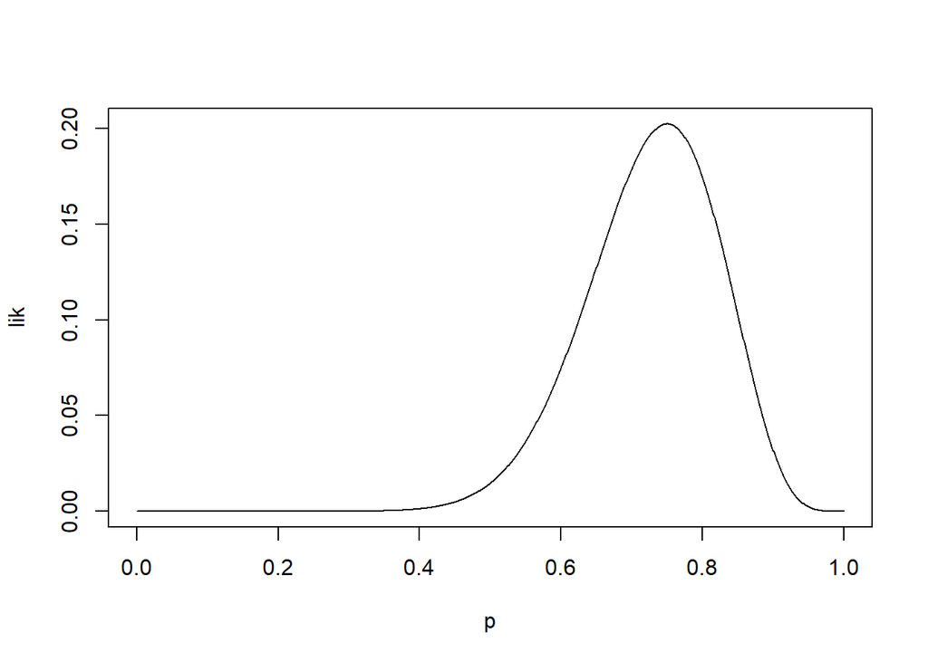

```r
p=seq(0,1,0.001)
lik=dbinom(15,20,p)
plot(p,lik,type="l")
```

If you look closely, you see that the likelihood is maximal at $p=0.75$. Note that `p` and `lik` are both vectors. We can now use R to find the value of `p` at which `lik` is maximal

```r
ind=which.max(lik)  # at which index is the vector "lik" maximal?
p[ind]              # what is the value of p at that index?
```

```
## [1] 0.75
```

So the maximum likelihood estimator of $p$ is 0.75, just as you would expect!

#### 4.1.0.2 Exercise

You have now seen an example of the method of maximum likelihood. Think about it; does it make sense to *you* to choose that value for the unknown parameter which maximizes the probability of the data?

**Click for the answer**

This Exercise is just to get you to think about it. Does the method of moments make more sense to you, or do you think maximum likelihood is very natural?

$~$

There is an important point about terminology. Recall the binomial probability mass function (PMF):
$$P(X=x) = {n \choose x} p^x (1-p)^{n-x},\quad x=0,1,2,\dots,n.$$

The PMF is a function of the outcome $x$ for some fixed value of $p$ (and $n$). It tells you, for any particular $p$, what the probabilities of the all possible outcomes are. However, we can *also* view it as a function of $p$ for the observed value of $x$ (and $n$). When we view the PMF as a function of the parameter, then we call it the *likelihood function*
$${\rm likelihood}(p) = {n \choose x} p^x (1-p)^{n-x}.$$

Since we often have independent observations, the likelihood is typically a product. For example, the binomial distribution arises from $n$ independent trials that each contribute zero or one to the total number of successes. So, the binomial likelihood is really a product terms that are either $p$ or $(1-p)$.

Now, both $p$ and $(1-p)$ are between zero and one. So when there are many terms in the product (when $n$ is large), it can become very small and that can cause numerical problems. For this reason – and many other reasons that will become clear later – it is better to work with the logarithm of the likelihood. The product becomes a sum and there will be no more numerical problems.

The parameter value at which the likelihood is maximized (that’s the MLE) is *also* the parameter value at which the *logarithm* of the likelihood is maximized. We will not prove that mathematically, but we can see it in our binomial example:

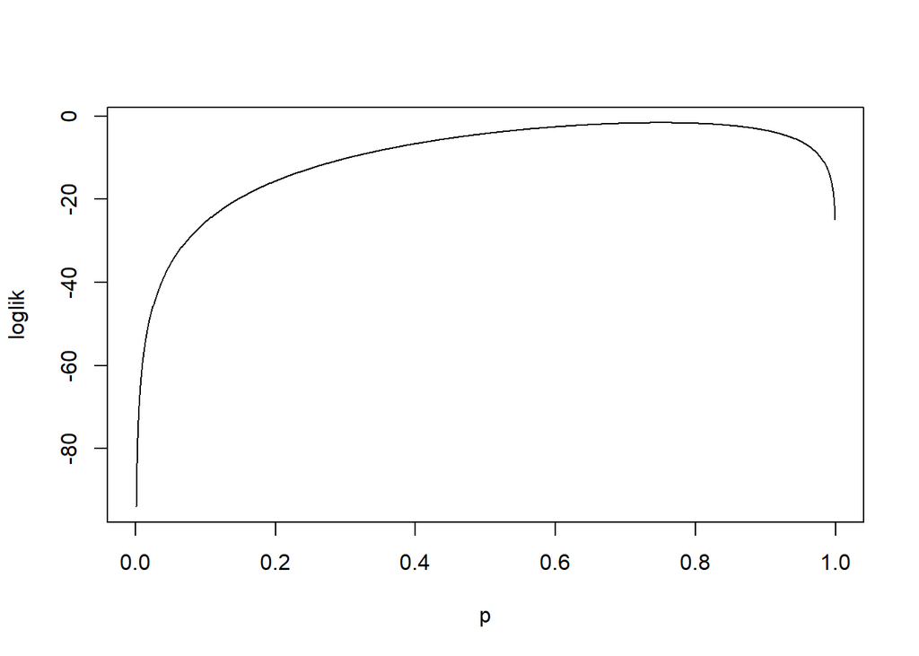

```r
p=seq(0,1,0.001)
loglik=dbinom(15,20,p,log=TRUE)  # notice the toggle "log=TRUE"
plot(p,loglik,type="l")
```

```r
ind=which.max(loglik)  # at which index is the vector "loglik" maximal?
p[ind]                 # what is the value of p at that index?
```

```
## [1] 0.75
```

## 4.2 Computing the MLE numerically

The recipe for finding the maximum likelihood estimator (MLE) is easy enough:

- Write down the log likelihood of the data
- Find the parameter value(s) at which the log likelihood is maximal.

Now let’s practice! We start with a discrete distribution.

$~$

#### 4.2.0.1 Excercise

Suppose that X is a discrete random variable with $P(X=0)=\frac{2}{3}\theta$, $P(X=1)=\frac13 \theta$, $P(X=2)=\frac23 (1-\theta)$ and $P(X=3)=\frac13(1-\theta)$. The following 10 independent observations were taken from such a distribution: (3, 0, 2, 1, 3, 2, 1, 0, 2, 1).

**Click for the answer**

1. The expected value of $X$ is
   $$E(X) = 0 \times \frac{2}{3}\theta + 1 \times \frac{1}{3}\theta + 2 \times \frac{2}{3}(1-\theta) + 3 \times \frac{1}{3}(1-\theta) = 7/3 - 2 \theta$$
   So, $\theta = (7/3 - EX)/2$ and the method of moments estimator is $(7/3 - \bar X)/2$

```r
x=c(3, 0, 2, 1, 3, 2, 1, 0, 2, 1)
(7/3 - mean(x))/2  # method of moments estimate
```

```
## [1] 0.4166667
```

2. The likelihood is

$$\text{lik}(\theta) = \left(\frac23 \theta\right)^2 \left(\frac13 \theta\right)^3\left(\frac23 (1-\theta)\right)^3 \left( \frac13(1-\theta) \right)^2$$

Ignoring the additive constant, the log likelihood is
$$\text{loglik}(\theta) = 5 \log(\theta) + 5 \log(1-\theta)$$

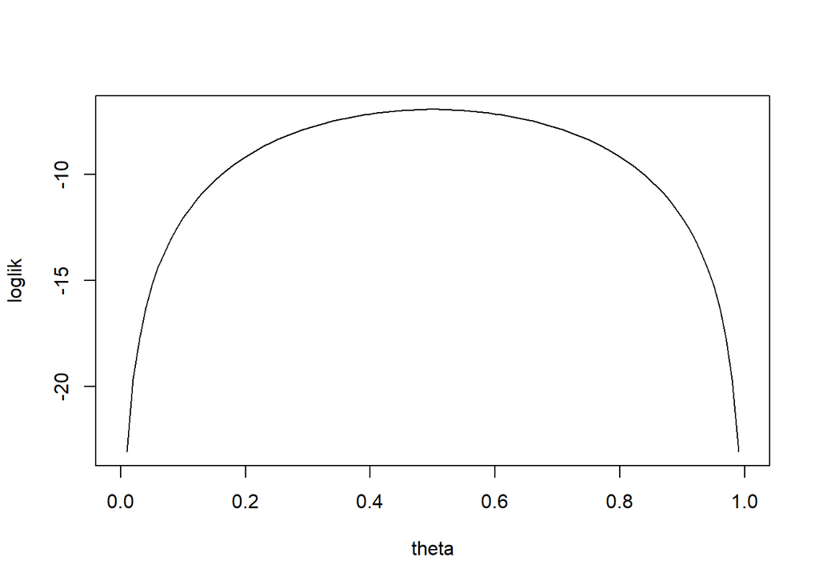

```r
theta=seq(0,1,0.01)
loglik=5*log(theta) + 5*log(1-theta)
plot(theta,loglik,type="l")
```

```r
ind=which.max(loglik)
theta[ind]                # mle
```

```
## [1] 0.5
```

$~$

#### 4.2.0.2 Exercise

If gene frequencies are in equilibrium, the genotypes AA, Aa, and aa occur in a population with frequencies $(1 − \theta)^2$, $2\theta(1 − \theta)$, and $\theta^2$, according to the Hardy- Weinberg law. Suppose that in a particular population of 1029 individuals, AA occurred 342 times, Aa 500 times, and aa 187 times.

**Click for the answer**

1. Let $X_1$, $X_2$ and $X_3$ denote the counts of AA, Aa and aa, respectively. The likelihood is

$$\text{lik}(\theta) = \left(1-\theta\right)^{2X_1} \left(2 \theta (1-\theta)\right)^{X_2} \theta^{2X_3}$$

The log likelihood is
$$\begin{align*}
\text{loglik}(\theta) &= 2X_1 \log(1 - \theta) + X_2\log(2) + X_2 \log(\theta) + X_2 \log(1-\theta) + 2X_3\log(\theta)\\
&= X_2\log(2) + (X_2+2X_3) \log(\theta) + (2X_1 +X_2) \log(1 - \theta)
\end{align*}$$

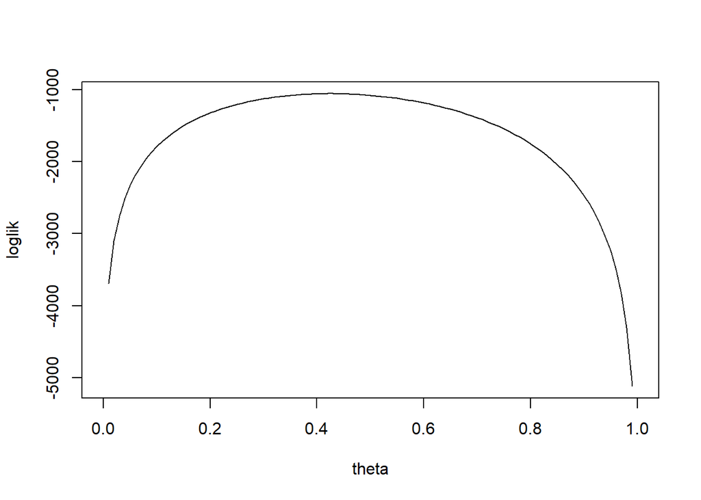

```r
x1=342
x2=500
x3=187
theta=seq(0,1,0.01)
loglik=x2*log(2) + (x2+2*x3)*log(theta) + (2*x1+x2)*log(1-theta)
plot(theta,loglik,type="l")
```

```r
ind=which.max(loglik)
theta[ind]                # mle
```

```
## [1] 0.42
```

$~$

Computing the likelihood on a grid of points and then using `which.max` is perhaps the easiest way to find the maximum likelihood estimator, but it is certainly not the best way. R has special routines, such as `optim` and `optimize` to maximize (likelihood) functions efficiently. These optimizers are faster and usually more accurate than doing a simple grid search. Efficient computation is a very important part of statistics nowadays.

To use `optimize` you must define a `function`. Here is how you can find the MLE for the peanut problem:

```r
loglik = function(p) {                      # define your own R function
  dbinom(15,20,p,log=TRUE)                  # that computes the log likelihood
}
optimize(loglik,interval=c(0,1),maximum=TRUE)  # mle=0.7499857, but you can increase the accuracy if needed.
```

```
## $maximum
## [1] 0.7499857
##
## $objective
## [1] -1.59785
```

#### 4.2.0.3 Exercise

In this case, the grid search (using `which.max`) got 0.75 which is *more* accurate than `optimize` getting 0.7499857. What happened?

**Click for the answer**

The grid we used happened to “hit” the maximum exactly. That’s just dumb luck!

$~$

#### 4.2.0.4 Exercise

During a thunderstorm, the weather service counts the number of lightning flashes in 5 subsequent 1 minute intervals. They find 17, 25, 17, 18, and 15 flashes.

1. Which probability distribution is appropriate to model these data?
2. Compute the method of moments estimate of the expected number of flashes per minute.
3. Write down the log likelihood (pen and paper), and plot it.
4. Find the MLE of the expected number of flashes per minute by maximizing the log likelihood using grid search (i.e. `which.max`).
5. Find the MLE using `optimize`.

**Click for the answer**

1. The “appropriate” distribution is the Poisson distribution. The likelihood is
   $${\rm likelihood}(\lambda) = \prod_{i=1}^5 \frac{\lambda^{x(i)}}{x(i)!} e^{-\lambda}$$
   The log likelihood is
   $${\rm loglikelihood}(\lambda) = \sum_{i=1}^5 \left( x(i) \log(\lambda) - \log(x(i)!) -\lambda \right)$$

```r
x=c(17,25,17,18,15)
mean(x)                        # method of moments = average = 18.4
```

```
## [1] 18.4
```

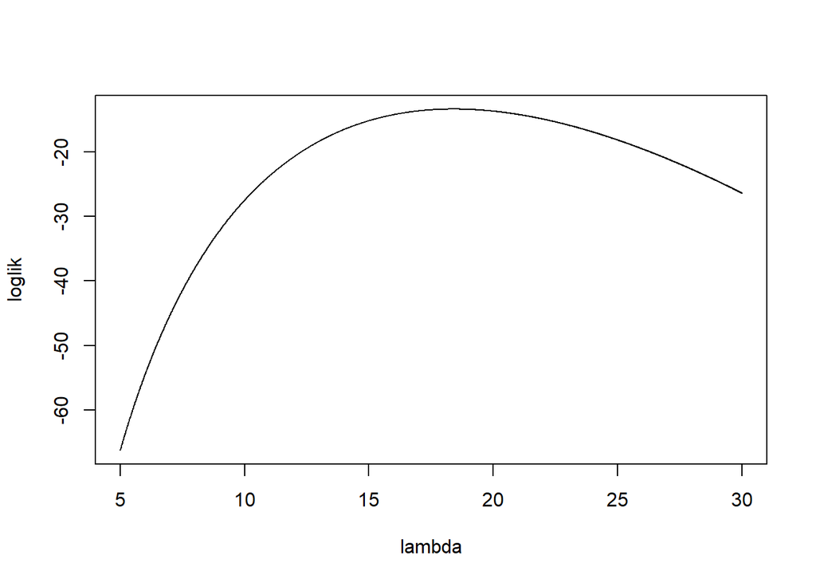

```r
lambda=seq(5,30,0.01)
loglik=0
for (i in 1:5){
  loglik = loglik + log(dpois(x[i],lambda))
}
plot(lambda,loglik,type='l')
```

4. Do grid search

```r
ind=which.max(loglik)
lambda[ind]                # mle = 18.4
```

```
## [1] 18.4
```

5. Use optimize,

```r
ll = function(lambda){
 sum(log(dpois(x,lambda)))
}
optimize(ll,c(0,100),maximum=TRUE)  # mle = 18.4
```

```
## $maximum
## [1] 18.4
##
## $objective
## [1] -13.37221
```

$~$

#### 4.2.0.5 Exercise

In part c. of the previous exercise we summed terms like `dpois(x[i],lambda,log=TRUE)` using a `for` loop where `lambda` is a vector. In part e. we used `sum(dpois(x,lambda,log=TRUE))` without a `for` loop. What’s the difference? What happens when you run the following code:

```r
x=c(17,25,17,18,15)
lambda=seq(5,30,0.01)
sum(dpois(x,lambda,log=TRUE))
```

**Click for the answer**

`dpois(x[1],lambda,log=TRUE)` computes the log probability of the first observation `x[1]=17` for all values `lambda`. Summing them up with a `for` loop computes the log likelihood of the five observations, for all values of `lambda`.

`dpois(x,lambda[1],log=TRUE)` computes the log probability of each of the five observations observation for one value of `lambda` (namely, `lambda[1]=5`). This is useful when you want `optimize` to find the value for lambda that optimizes the log likelihood of the five observations.

It’s is not clear what`dpois(x,lambda,log=TRUE)` is supposed to do, and `R` will do something that is not useful.

$~$

#### 4.2.0.6 Exercise

With every 5 euros spent on groceries, you get a card with picture of a dutch soccer player. One soccer fan is only interested in pictures of Memphis Depay. After collecting 23 pictures of undistinguished players, he gets his first Memphis!

1. Which probability distribution is appropriate to model these data?
2. Compute is the method of moments estimate of the probability of finding a Memphis?
3. Write down the log likelihood (pen and paper), and plot it.
4. Find the MLE of the probability of finding a Memphis by using `which.max`.
5. Find the MLE by using `optimize`.

**Click for the answer**

1. The “appropriate” distribution is the Geometric distribution. The likelihood is
   $${\rm likelihood}(p) = (1-p)^{23}p$$
   The log likelihood is
   $${\rm loglikelihood}(p) = 23 \log(1-p) + \log(p)$$
   The probability of success is quite small, and so we use a small grid to optimize.

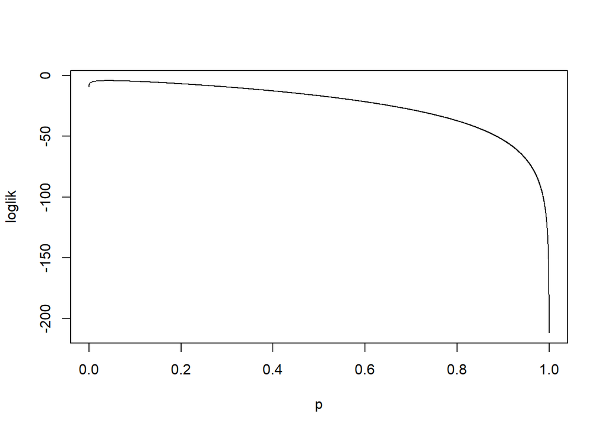

```r
p=seq(0.0001,1,0.0001)
loglik=dgeom(23,p,log=TRUE)
plot(p,loglik,type='l')
```

```r
ind=which.max(loglik)
p[ind]             # mle = 0.0417
```

```
## [1] 0.0417
```

Better to use optimize

```r
loglik = function(p){
 dgeom(23,p,log=TRUE)
}
optimize(loglik,c(0,1),maximum=TRUE)  # mle = 0.0417
```

```
## $maximum
## [1] 0.04166196
##
## $objective
## [1] -4.156925
```

$~$ Now let us try a little “missing data problem”.

#### 4.2.0.7 Exercise

To be very honest, the Memphis-fan of the previous exercise actually was not very careful about keeping track of the number of cards he collected. He really only knows for sure that he collected between 20 and 24 cards before his first Memphis.

1. Write down the log likelihood (pen and paper), and plot it.
2. Maximize the loglikelihood and find the MLE of the probability of finding a Memphis.

**Click for the answer**

1. The likelihood is
   $${\rm likelihood}(p) = (1-p)^{20}p + (1-p)^{21}p + (1-p)^{22}p + (1-p)^{23}p + (1-p)^{24}p$$
   The log likelihood is just the log of the likelihood. There is no nice expression, though. To plot the log likelihood

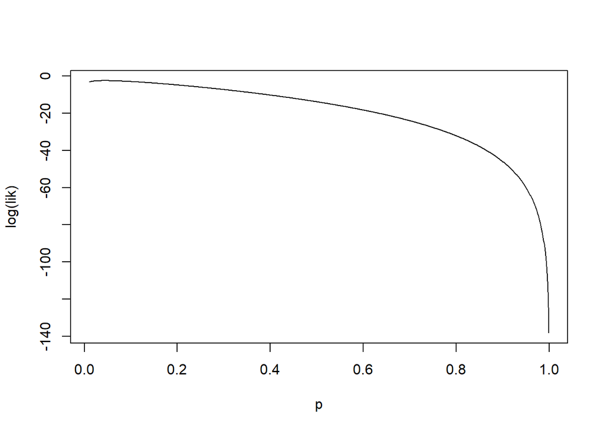

```r
p=seq(0.01,1,0.001)
lik=dgeom(20,p) + dgeom(21,p) + dgeom(22,p) + dgeom(23,p) + dgeom(24,p)
plot(p,log(lik),type="l")
```

```r
# and maximize:
loglik = function(p){
 log(sum(dgeom(20:24,p)))
}
optimize(loglik,c(0,1),maximum=TRUE)  # mle = 0.0436
```

```
## $maximum
## [1] 0.04364423
##
## $objective
## [1] -2.502012
```

$~$

This last exercise demonstrates why the method of maximum likelihood is much more versatile than the method of moments. Indeed, there is no obvious way to apply the method of moments to this type of incomplete or “censored” data.

$~$

Now let us do a continuous distribution. The likelihood is simply the product of the densities at the data points. Again, we prefer to work with the logarithm of the likelihood.

#### 4.2.0.8 Exercise

Suppose a supermarket sells potatoes in 1 kilo bags. We buy 7 bags and weigh them. We find (in grams) $X_1=983,\ X_2=1041,\ X_3=1026,\ X_4=1025,\ X_5=1033,\ X_6=968,\ X_7=1028$. Suppose we know that the (population) standard deviation of the weights is 25 grams.

1. Which probability distribution is appropriate to model these data?
2. Compute is the method of moments estimate of the (population) average weight.
3. Write down the log likelihood (pen and paper), and plot it.
4. Maximize the loglikelihood and and find the MLE of the (population) average weight.

**Click for the answer**

The “appropriate” distribution is the normal distribution. The likelihood is:”
$${\rm likelihood}(\mu) = \prod_{i=1}^{7} \frac{1}{\sigma \sqrt{2 \pi}} e^{-(x(i) - \mu)^2/2\sigma^2}$$
The log likelihood is
$${\rm loglikelihood}(\mu) = \sum_{i=1}^{7} [ -\log(\sigma \sqrt{2 \pi}) - (x(i)-\mu)^2/2\sigma^2 ]$$

2. The method of moments estimate of the expectation is just the average.

```r
x=c(983,1041,1026,1025,1033,968,1028)
mean(x)
```

```
## [1] 1014.857
```

3. Compute the MLE:

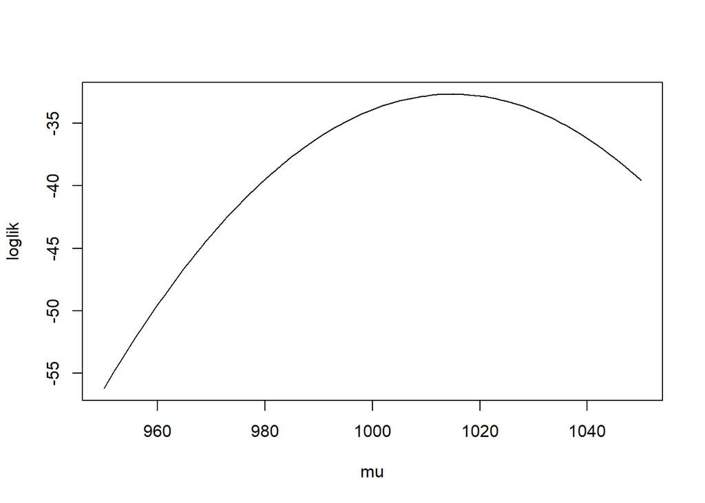

```r
mu=seq(950,1050,1)     # "guessing" the MLE is somewhere between 950 and 1050
loglik=0
for (i in 1:7){
  loglik = loglik + log(dnorm(x[i],mu,25))
}
plot(mu,loglik,type='l')
```

```r
# use grid search
ind=which.max(loglik)
mu[ind]        # mle of mu
```

```
## [1] 1015
```

```r
# or, using optimize,
ll = function(mu){
 sum(log(dnorm(x,mu,25)))
}
optimize(ll,c(0,2000),maximum=TRUE)  # mle of mu
```

```
## $maximum
## [1] 1014.857
##
## $objective
## [1] -32.66299
```

$~$

#### 4.2.0.9 Exercise

A manufacturer tests 10 light bulbs and records how many months they burn continuously before burning out. She finds 8.5, 2.3, 11.0, 22.5, 13.6, 5.8, 27.3, 13.1, 0.9 and 3.1 months.

1. Which probability distribution is appropriate to model these data?
2. Compute is the method of moments estimate of the expected number of burning months.
3. Write down the log likelihood (pen and paper), and plot it.
4. Maximize the loglikelihood and and find the MLE of the expected number of burning months.

**Click for the answer**

1. The “appropriate” distribution is the Exponential distribution. The Exponential distribution is parametrized by the “rate” lambda, which is 1/expectation. The likelihood is:
   $${\rm likelihood}(\lambda) = \prod_{i=1}^{10} \lambda e^{-\lambda x(i)}$$
   The log likelihood is
   $${\rm loglikelihood}(\lambda) = \sum_{i=1}^{10} [ \log(\lambda) - \lambda x(i) ]$$
2. The method of moments estimate of the expectation is just the average.

```r
x=c(8.5, 2.3, 11.0, 22.5, 13.6, 5.8, 27.3, 13.1, 0.9, 3.1)
mean(x)
```

```
## [1] 10.81
```

3. Compute the MLE:

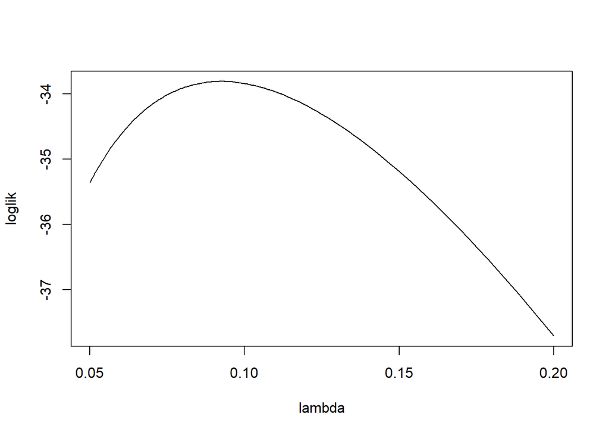

```r
expectation=seq(5,20,0.1)     # "guessing" the MLE is somewhere between 5 and 20
lambda=1/expectation
loglik=0
for (i in 1:10){
  loglik = loglik + log(dexp(x[i],lambda))
}
plot(lambda,loglik,type='l')
```

```r
# use grid search
ind=which.max(loglik)
lambda[ind]        # mle of lambda
```

```
## [1] 0.09259259
```

```r
1/lambda[ind]      # mle of 1/lambda (same as expectation[ind])
```

```
## [1] 10.8
```

```r
# or, using optimize,
ll = function(lambda){
 sum(log(dexp(x,lambda)))
}
optimize(ll,c(0,20),maximum=TRUE)  # mle of lambda
```

```
## $maximum
## [1] 0.09251358
##
## $objective
## [1] -33.80472
```

```r
1/0.09251358                       # mle of 1/lambda
```

```
## [1] 10.80922
```

$~$

We can also mix densities and actual probabilities.

#### 4.2.0.10 Exercise

A manufacturer tests **11** light bulbs and records how many months they burn continuously before burning out. She finds 8.5, 2.3, 11.0, 22.5, 13.6, 5.8, 27.3, 13.1, 0.9 and 3.1 months. The eleventh bulb is still burning at 24 months when the experiment ends.

1. Write down the log likelihood (pen and paper), and plot it.
2. Maximize the loglikelihood and and find the MLE of the expected number of burning months.

**Click for the answer**

1. The cumulative distribution function of the exponential distribution is
   $$F(x) = 1 - exp(-\lambda x)$. So $P(X>24) = exp(-\lambda 24).$$
   The likelihood now becomes:
   $${\rm likelihood}(\lambda) = e^{-\lambda x(11)} \prod_{i=1}^{10} \lambda e^{-\lambda x(i)}$$
   The log likelihood is
   $${\rm loglikelihood}(\lambda) = -\lambda x(11) + \sum_{i=1}^{10} [ \log(\lambda) - \lambda x(i) ]$$

The appropriate distribution is the Exponential. R parametrizes the exponential distribution by its “rate” which is 1/expectation.

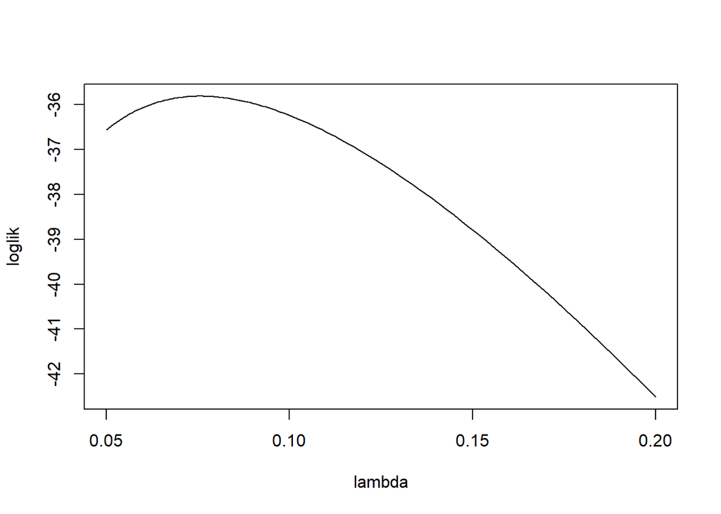

```r
x=c(8.5, 2.3, 11.0, 22.5, 13.6, 5.8, 27.3, 13.1, 0.9, 3.1, 24)  # add X_11

expectation=seq(5,20,0.1)     # "guessing" the MLE is somewhere between 5 and 20
lambda=1/expectation
loglik=0
for (i in 1:10){
  loglik = loglik + log(dexp(x[i],lambda))
}
loglik = loglik + log(1 - pexp(x[11],lambda)) # the prob of lasting longer than 24.
plot(lambda,loglik,type='l')
```

```r
# use grid search
ind=which.max(loglik)
lambda[ind]        # mle of lambda
```

```
## [1] 0.07575758
```

```r
1/lambda[ind]      # mle of 1/lambda (same as expectation[ind])
```

```
## [1] 13.2
```

```r
# or, using optimize,
ll = function(lambda){
 sum(log(dexp(x[1:10],lambda)))  + log(1 - pexp(x[11],lambda))
}
optimize(ll,c(0,1),maximum=TRUE) # mle of lambda
```

```
## $maximum
## [1] 0.07568509
##
## $objective
## [1] -35.80974
```

```r
1/0.07568509                     # mle of 1/lambda
```

```
## [1] 13.21264
```

$~$

#### 4.2.0.11 Exercise

The “lasso” is a very popular method in machine learning and statistics. It is based on the Laplace distribution, which is also known as the double exponential distribution. This distribution has the following density
$$f_\theta(x) = \frac{1}{2\theta} e^{-|x|/\theta} \qquad (\theta>0)$$

1. Plot the density for a few values of $\theta$. Why is it called the double exponential distribution?
2. Suppose we observe `x=c(4.77,5.52,0.38,1.13,21.86,13.79,12.61,1.01,13.96,2.37)`. Plot the log likelihood function.
3. What is the maximum likelihood estimator of $\theta$?

**Click for the answer**

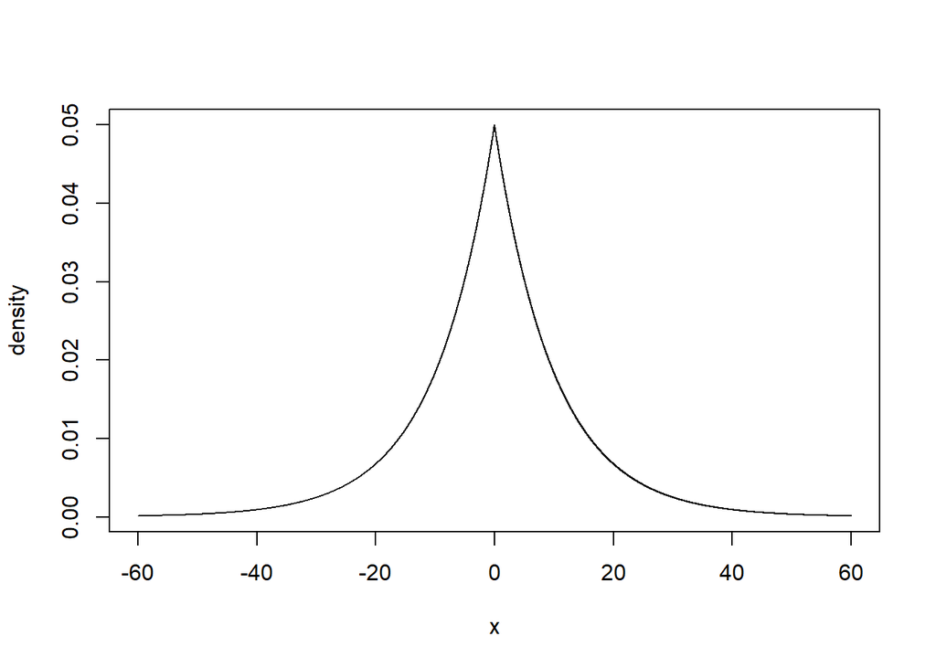

```r
theta=10
x=seq(-60,60,0.01)
plot(x,exp(-abs(x)/theta)/(2*theta),type="l",ylab="density")
```

2. The likelihood is:
   $${\rm likelihood}(\theta) = \prod_{i=1}^{10} \frac{1}{2\theta} e^{-|x_i|/\theta}$$

and the log likelihood is
$${\rm loglikelihood}(\theta) = \sum_{i=1}^{10} -\log(2\theta) - |x_i|/\theta$$

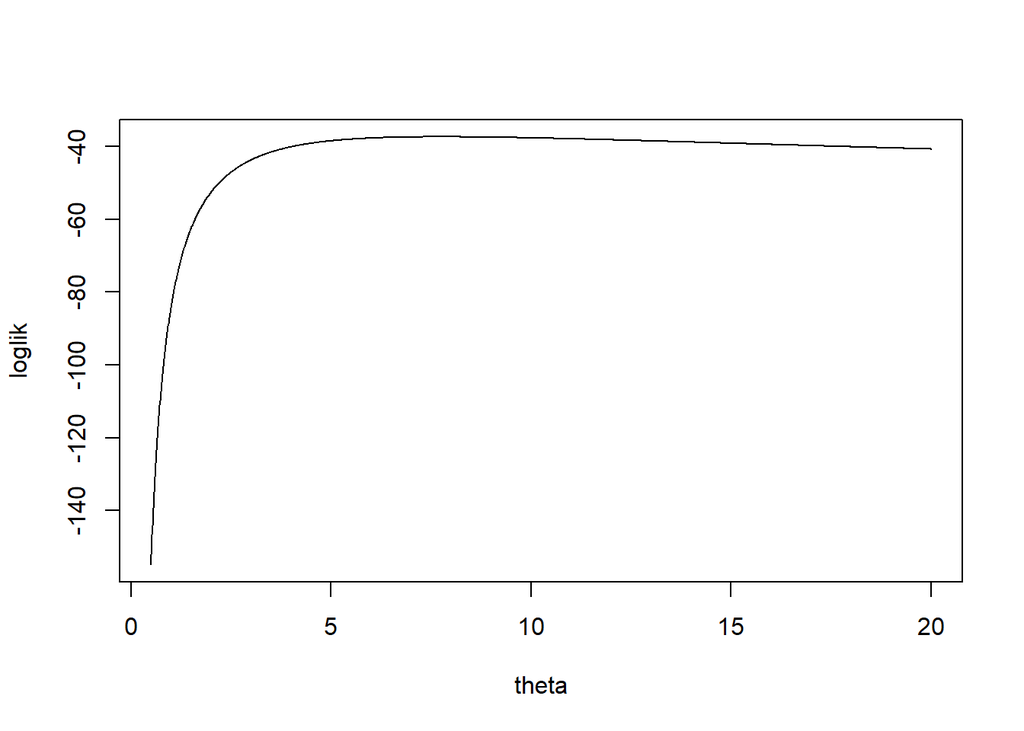

```r
theta=seq(0.5,20,0.01)
x=c(4.77,5.52,0.38,1.13,21.86,13.79,12.61,1.01,13.96,2.37)
loglik=0
for (i in 1:10){
  loglik = loglik -log(2*theta)-abs(x[i])/theta
}
plot(theta,loglik,type="l")
```

```r
theta[which.max(loglik)]   # mle
```

```
## [1] 7.74
```

```r
# or, using optimize,
ll = function(theta){
 sum(-log(2*theta)-abs(x)/theta)
}
optimize(ll,c(0,100),maximum=TRUE) # mle
```

```
## $maximum
## [1] 7.740004
##
## $objective
## [1] -37.39549
```

$~$

Finally, let’s do a problem with a discrete parameter.

$~$

#### 4.2.0.12 Exercise

The capture-recapture method was used to estimate the size of an animal population. First, 100 animals are captured and tagged. Some time later, another 50 animals are captured, and it is found that 20 of them are tagged.

1. Write down the likelihood. Hint: consider the so-called [hypergeometric distribution](https://en.wikipedia.org/wiki/Hypergeometric_distribution).
2. Use the R function `dhyper` to plot the likelihood.
3. Compute the MLE of the population size.

**Click for the answer**

1. If the size of the population is $N$, then the probability of the observation is $\frac{{100 \choose 20}{N-100 \choose 30}}{{N \choose 50}}$.

b/c.

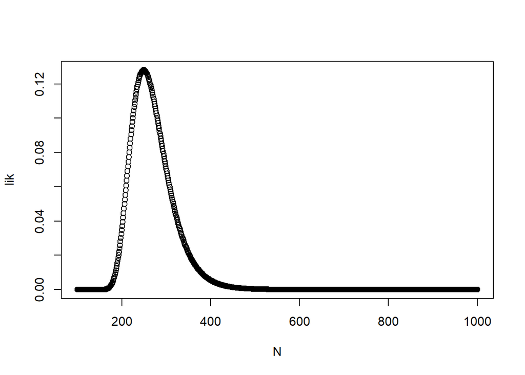

```r
N=100:1000         # guess the population is somewhere between 100 and 1000
lik=dhyper(20,100,N-100,50)
plot(N,lik)
```

```r
N[which.max(lik)]  # MLE
```

```
## [1] 249
```

In this case, `optimize` is not a very good choice, because the inputs of `dhyper` must be integers. However, we can fix this problem by rounding:

```r
lik.fun = function(N){
  N=round(N)
  dhyper(20,100,N-100,50)
}
optimize(lik.fun,interval=c(0,1000),maximum=TRUE)
```

```
## $maximum
## [1] 249.2378
##
## $objective
## [1] 0.1280466
```

$~$

We end this section with an example where we estimate two parameters *simultaneously*. This will not be part of the exam!

Suppose a supermarket sells potatoes in 1 kilo bags. We buy 7 bags and weigh them. We find (in grams) $X_1=983,\ X_2=1041,\ X_3=1026,\ X_4=1025,\ X_5=1033,\ X_6=968,\ X_7=1028$. Suppose we do *not* know the standard deviation of the weights.

If we are willing to assume that these weights follow the normal probability distribution, we can apply the method of maximum likelihood to estimate the two parameters $\mu$ and $\sigma$.

$~$

#### 4.2.0.13 Exercise

Are you “willing to assume the weights follow a normal distribution”?

**Click for the answer**

The trouble is that there is really no way to tell based on a sample of just 7 bags. However, there are no obvious outliers that could throw everything off, so it is pretty safe to assume normality.

$~$

Here is some *very* inefficient code to compute the MLE. It works by trying out many combinations of $\mu$ and $\sigma$ and always keeping the ones that increase the log likelihood. In the end we are left with the pair that maximizes the likelihood.

```r
x=c(983,1041,1026,1025,1033,968,1028)
loglik=-Inf
for (m in seq(900,1100,0.1)){
  for (s in seq(10,40,0.1)){
     tmp=sum(log(dnorm(x,m,s)))  # compute the loglikelihood by summing
     if (tmp>loglik){
        loglik=tmp
        mu=m
        sigma=s
     }
  }
}
mu
```

```
## [1] 1014.9
```

```r
sigma
```

```
## [1] 25.7
```

#### 4.2.0.14 Exercise

Read the code, make sure you understand it, and run it. What is bad or inefficient about it?

**Click for the answer**

We have to start by choosing some reasonable values for mu and sigma, and that is not so easy. And even then, we still spend a lot of time evaluating the log likelihood at parameter values that are nowhere near the optimum.

$~$

To find the MLE, it’s much better to use an optimizer. Until now we have used `optimize` but that can only optimize functions of a single parameter. To handle two parameters, we can use `optim`.

```r
x=c(983,1041,1026,1025,1033,968,1028)
ll = function(theta,x) {         # We define an R function that computes the log likelihood
   mu=theta[1]
   sigma=theta[2]
   -sum(log(dnorm(x,mu,sigma)))  # compute loglikelihood by summing
}                                # add a minus sign, because optim *minimizes*.
optim(c(1000,25),ll,x=x,method="BFGS")
```

```
## $par
## [1] 1014.86313   25.69854
##
## $value
## [1] 32.65757
##
## $counts
## function gradient
##       21       18
##
## $convergence
## [1] 0
##
## $message
## NULL
```

#### 4.2.0.15 Exercise

Run the code.

**Click for the answer**

Fast, isn’t it?

## 4.3 What have we learned

- We know the method of maximum likelihood
- We can write down the likelihood (and log likelihood) in some standard situations
- We can compute the maximum likelihood estimator
  - by grid search
  - by using `optimize`

$~$

# 5 The score function

We now know how to write down the likelihood for our data and use it to find the maximum likelihood estimator. The likelihood has many more uses than just for finding the maximum likelihood estimator, however! Today, we’ll explore the concept of likelihood in more depth. Throughout, we will focus on the log likelihood.

We will see that the log likelihood is much a more useful and fundamental concept than the likelihood itself. You will often notice that statisticians, when speaking about the likelihood, actually mean the log likelihood.

## 5.1 Computing the MLE exactly

If the log likelihood is not too complicated, then we can use mathematics to find the maximum. The basic idea is to take the derivative of the log likelihood and set it equal to zero. For example, consider the binomial model. If we have $x$ successes out of $n$ tries, then the likelihood is
$${\rm lik}(p) = {n \choose x} p^x (1-p)^{n-x},$$

and the log likelihood is
$${\rm loglik}(p) = \log {n \choose x} + x \log(p) + (n-x) \log(1-p).$$
Taking the derivative with respect to $p$ (remember the chain rule!) and bringing to a common denominator, we get
$${\rm loglik}'(p) = \frac{x}{p} - \frac{n-x}{1-p} = \frac{x - np}{p(1-p)}.$$
Now we set this equal to zero and solve for $p$. That means solving $x-np=0$, so we find $\hat p=x/n$. That’s the MLE *exactly*.

$~$

#### 5.1.0.1 Excercise

Suppose that X is a discrete random variable with $P(X=0)=\frac{2}{3}\theta$, $P(X=1)=\frac13 \theta$, $P(X=2)=\frac23 (1-\theta)$ and $P(X=3)=\frac13(1-\theta)$. The following 10 independent observations were taken from such a distribution: (3, 0, 2, 1, 3, 2, 1, 0, 2, 1). Maximize the loglikelihood and find the MLE.

**Click for the answer**

The likelihood is

$$\text{lik}(\theta) = \left(\frac23 \theta\right)^2 \left(\frac13 \theta\right)^3\left(\frac23 (1-\theta)\right)^3 \left( \frac13(1-\theta) \right)^2$$

The log likelihood is
$$\text{loglik}(\theta) = 2 \log(\frac23 \theta) + 3 \log(\frac13 \theta) + 3 \log(\frac23(1-\theta)) + 2 \log(\frac13(1-\theta))$$

Taking the derivative, we get
$$\text{loglik}'(\theta) = \frac2\theta + \frac3\theta - \frac3{(1-\theta)} - \frac2{(1-\theta)} = \frac5\theta - \frac5{(1-\theta)}$$

Setting this derivative to zero, we get
$$\frac5\theta = \frac5{(1-\theta)}.$$
Equivalently, $\theta = (1-\theta)$, so $2 \theta =1$, so $\theta = 1/2.$

$~$

#### 5.1.0.2 Exercise

If gene frequencies are in equilibrium, the genotypes AA, Aa, and aa occur in a population with frequencies $(1 − \theta)^2$, $2\theta(1 − \theta)$, and $\theta^2$, according to the Hardy- Weinberg law. Suppose that in a particular population of 1029 individuals, AA occurred 342 times, Aa 500 times, and aa 187 times. Maximize the loglikelihood and find the MLE of $\theta$.

**Click for the answer**

1. Let $X_0$, $X_1$ and $X_2$ denote the counts of AA, Aa and aa, respectively. The likelihood is

$$\text{lik}(\theta) = \left(1-\theta\right)^{2X_0} \left(2 \theta (1-\theta)\right)^{X_1} \theta^{2X_2}$$

The log likelihood is
$$\begin{align*}
\text{loglik}(\theta) &= 2X_0 \log(1 - \theta) + X_1\log(2) + X_1 \log(\theta) + X_1 \log(1-\theta) + 2X_2\log(\theta)\\
&= X_1\log(2) + (X_1+2X_2) \log(\theta) + (2X_0 +X_1) \log(1 - \theta)
\end{align*}$$
We can take the derivative as
$$\begin{align*}
\text{loglik}'(\theta) &= \frac{X_1+2X_2}\theta -\frac{2X_0 +X_1}{1 - \theta}
\end{align*}$$

Setting to zero, we get

$$\begin{align*}
\frac{X_1+2X_2}\theta -\frac{2X_0 +X_1}{1 - \theta} &= 0 \\
(X_1+2X_2)(1-\theta) &= (2X_0 +X_1) \theta \\
X_1+2X_2 &= (2X_0 + 2 X_1 + 2 X_2)\theta \\
\frac{X_1+2X_2}{2X_0 + 2 X_1 + 2 X_2} &= \theta
\end{align*}$$

In our data $\theta = (2*187 + 500)/(2*1029) = 0.425$.

$~$

#### 5.1.0.3 Exercise

With every 5 euros spent on groceries, you get a card with a picture of a dutch soccer player. One soccer fan is only interested in pictures of Memphis Depay. After collecting 23 pictures of undistinguished players, he gets his first Memphis! Write down the likelihood, and compute the MLE of the probability of getting a Memphis.

**Click for the answer**

1. The “appropriate” distribution is the Geometric distribution. The likelihood is
   $${\rm likelihood}(p) = (1-p)^{23}p$$
   The log likelihood is
   $${\rm loglikelihood}(p) = 23 \log(1-p) + \log(p)$$
   Taking the derivative with respect to p
   $${\rm loglikelihood'}(p) = -23/(1-p) + 1/p = (-24p + 1)/p(1-p)$$
   Setting equal to zero, we get $p=1/24=0.0417.$

$~$

#### 5.1.0.4 Exercise

During a thunderstorm, the weather service counts the number of lightning flashes in 5 subsequent 1 minute intervals. They find 17, 25, 17, 18, and 15 flashes. Write down the likelihood, and compute the MLE of the expectation lambda.

**Click for the answer**

The “appropriate” distribution is the Poisson distribution. The likelihood is
$${\rm likelihood}(\lambda) = \prod_{i=1}^5 \frac{\lambda^{x(i)}}{x(i)!} e^{-\lambda}$$
The log likelihood is
$${\rm loglikelihood}(\lambda) = \sum_{i=1}^5 \left( x(i) \log(\lambda) - \log(x(i)!) -\lambda \right)$$
The derivative with respect to lambda is
$${\rm loglikelihood'}(\lambda) = \sum_{i=1}^5 x(i)/\lambda - n$$
Setting equal to zero, we find $\hat \lambda = \sum_{i=1}^5 x(i) / n$

```r
mean(c(17, 25, 17, 18, 15))
```

```
## [1] 18.4
```

$~$

#### 5.1.0.5 Exercise

A manufacturer tests 10 light bulbs and records how many months they burn continuously before burning out. She finds 8.5, 2.3, 11.0, 22.5, 13.6, 5.8, 27.3, 13.1, 0.9 and 3.1 months. Write down the likelihood, and compute the MLE of the expected number of burning months.

**Click for the answer**

The “appropriate” distribution is the Exponential distribution. The Exponential distribution is parametrized by the “rate” lambda, which is the reciprocal of the expected waiting time. So, we’ll estimate lambda, and then take the reciprocal. The likelihood is

$${\rm likelihood}(\lambda) = \prod_{i=1}^{10} \lambda e^{-\lambda x(i)}$$
The log likelihood is
$${\rm loglikelihood}(\lambda) = \sum_{i=1}^{10} [ \log(\lambda) - \lambda x(i) ]$$
The derivative with respect to lambda is
$${\rm loglikelihood'}(\lambda) = \sum_{i=1}^{10} [1/\lambda - x(i) ] = 10/\lambda - \sum_{i=1}^{10} x(i)$$
Setting equal to zero, we find $\hat \lambda = 10 / \sum_{i=1}^{10} x(i)$. So for the expected waiting time we find $1/\hat \lambda = \sum_{i=1}^{10} x(i)/10$

```r
mean(c(8.5, 2.3, 11.0, 22.5, 13.6, 5.8, 27.3, 13.1, 0.9, 3.1))
```

```
## [1] 10.81
```

$~$

#### 5.1.0.6 Exercise

Suppose a supermarket sells potatoes in 1 kilo bags. We buy 7 bags and weigh them. We find (in grams) $X_1=983,\ X_2=1041,\ X_3=1026,\ X_4=1025,\ X_5=1033,\ X_6=968,\ X_7=1028$. Suppose we know that the (population) standard deviation of the weights is 25 grams. Write down the likelihood, and compute the MLE of the population average.

**Click for the answer**

1. The “appropriate” distribution is the normal distribution. The likelihood is:

$${\rm likelihood}(\mu) = \prod_{i=1}^{7} \frac{1}{\sigma \sqrt{2 \pi}} e^{-(x(i) - \mu)^2/2\sigma^2}$$
The log likelihood is

$${\rm loglikelihood}(\mu) = \sum_{i=1}^{7} [ -\log(\sigma \sqrt{2 \pi}) - (x(i)-\mu)^2/2\sigma^2 ]$$
Taking the derivative with respect to $\mu$

$${\rm loglikelihood'}(\mu) = \sum_{i=1}^{7} [ (x(i) - \mu)/\sigma^2]$$
Setting equal to zero, we get $\mu = \sum_{i=1}^{7}x(i)/7$.

```r
mean(c(983,1041,1026,1025,1033,968,1028))
```

```
## [1] 1014.857
```

$~$

#### 5.1.0.7 Exercise

The “lasso” is a very popular method in machine learning and statistics. It is based on the Laplace distribution, which is also known as the double exponential distribution. This distribution has the following density
$$f_\theta(x) = \frac{1}{2\theta} e^{-|x-\mu|/\theta} \qquad (\theta>0)$$
Suppose we observe `x=c(-4.77,5.52,-0.38,1.13,21.86,-13.79,-12.61,-1.01,13.96,2.37)`, and that $\mu=0$ is known. What is the maximum likelihood estimator of $\theta$?

**Click for the answer**

The likelihood is:
$${\rm likelihood}(\theta) = \prod_{i=1}^{n} \frac{1}{2\theta} e^{-|x_i|/\theta}$$

and the log likelihood is
$${\rm loglikelihood}(\theta) = \sum_{i=1}^{n} (-\log(2\theta) - |x_i|/\theta) = -n\log(2\theta) - \frac1\theta \sum_{i=1}^{n}|x_i|$$
We take the derivative

$${\rm loglikelihood}'(\theta) = -\frac n\theta + \frac1{\theta^2} \sum_{i=1}^{n}|x_i|.$$
Setting to zero, we have
$$\frac n\theta = \frac1{\theta^2} \sum_{i=1}^{n}|x_i|,$$
which we solve as $\theta = \frac1n \sum_{i=1}^{n}|x_i|$.

```r
x=c(-4.77,5.52,-0.38,1.13,21.86,-13.79,-12.61,-1.01,13.96,2.37)
mean(abs(x))
```

```
## [1] 7.74
```

$~$

#### 5.1.0.8 Exercise

Continuing from the previous exercise, suppose that $\theta=5$ is known. Make a plot of the log likelihood of $\mu$. Do you think you can find the MLE by differentiating? If not, why?

**Click for the answer**

The likelihood is:
$${\rm likelihood}(\mu) = \prod_{i=1}^{n} \frac{1}{10} e^{-|x_i-\mu|/5}$$

and the log likelihood is
$${\rm loglikelihood}(\mu) = \sum_{i=1}^{n} (-\log(10) - |x_i-\mu|/5) = -n\log(10) - \frac15 \sum_{i=1}^{n}|x_i-\mu|$$

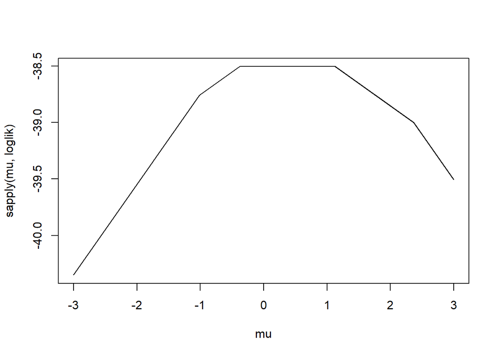

```r
x=c(-4.77,5.52,-0.38,1.13,21.86,-13.79,-12.61,-1.01,13.96,2.37)
n = length(x)
theta=5
loglik = function(mu) -n*log(2*theta) - sum(abs(x-mu))/theta
mu = seq(-3, 3, by=.001)
plot(mu, sapply(mu, loglik), type='l')
```

We cannot find the MLE by differentiating, because it the curve is angular rather than smooth (``not differentiable’’) and has a completely flat top.

$~$

Setting the derivative of the log likelihood equal to zero often works to find the MLE, but not always!

#### 5.1.0.9 Exercise

Suppose we have a sample $X_1,X_2,\dots,X_{5}$ from the uniform distribution on $[0,\theta]$.

1. Start by writing down the likelihood.
2. Now, we generate some data:

```r
set.seed(123)
x=runif(5,0,3.14)
x
```

```
## [1] 0.9029934 2.4752781 1.2841875 2.7726746 2.9530673
```

Plot the likelihood. Find the MLE of $\theta$ both with pen-and-paper and with `R`.

**Click for the answer**

1. The likelihood is just
   $${\rm likelihood}(\theta) = \prod_{i=1}^{5} \frac{1}{\theta}=1/\theta^5$$
   when $\theta$ is greater than the maximum of the $x(i)$, and zero otherwise!
2. Now generate some data

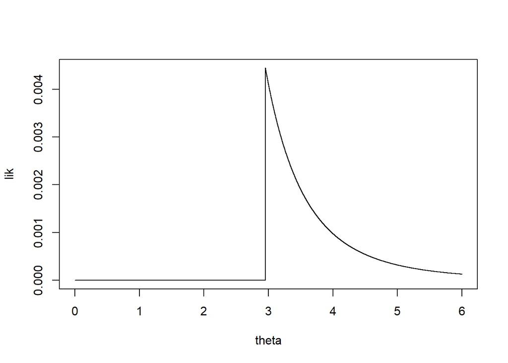

```r
set.seed(123)
x=runif(5,0,3.14)
theta=seq(0,6,0.001)
lik=(theta > max(x))*(1/theta)^5
plot(theta,lik,type="s")
```

```r
# The MLE is max(x)
max(x)
```

```
## [1] 2.953067
```

## 5.2 The (log) likelihood is random

Given a model, we can calculate a likelihood for a data set. Suppose we have data that we can assume to come from an exponential distribution.

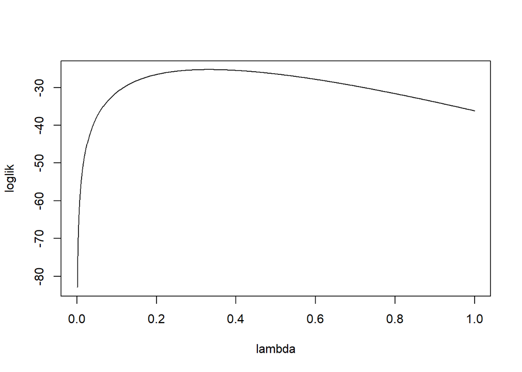

```r
X <- c(1.0, 5.2, 2.1, 9.3, 0.7, 1.5, 2.5, 0.9, 1.0, 3.8, 6.6, 1.6)
loglik.fun <- function(lambda) sum(dexp(X, rate=lambda, log=TRUE))
lambda <- seq(0,1,by=0.001)
loglik <- sapply(lambda, loglik.fun)
plot(lambda, loglik, type='l')
```

However, since the likelihood-function depends on the data, it has a sampling distribution. Every time we generate new data, we have a different likelihood.

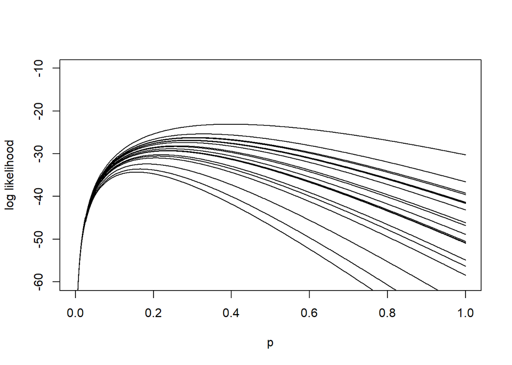

```r
plot(1, type="n", xlim=0:1, ylim=c(-60,-10), xlab="p", ylab="log likelihood")
funs <- replicate(20, {
  X <- rexp(12, rate=1/4)
  loglik.fun <- function(lambda) sum(log(dexp(X, rate=lambda)))
  lambda <- seq(0,1,by=0.001)
  loglik <- sapply(lambda, loglik.fun)
  lines(lambda, loglik)
})
```

The randomness of the likelihood is something you should keep in mind during the rest of this lecture. It means that most things we calculate from the likelihood are also random.

$~$

#### 5.2.0.1 Exercise

Visualize the sampling distribution of the log likelihood of $p$ when sampling 12 Bernoulli variables with a true probability of 0.3. Draw 20 random curves. Why are there less than 20 lines in the plot you have just made? Why do all the log likelihoods intersect when $p=0.5$?

**Click for the answer**

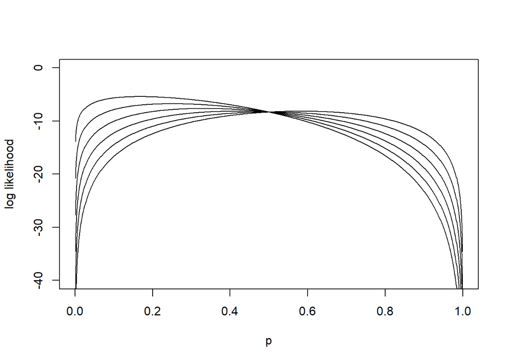

```r
plot(1, type="n", xlim=0:1, ylim=c(-40,0), xlab="p", ylab="log likelihood")
funs <- replicate(20, {
  X <- rbinom(12, size=1, prob=0.3)
  loglik.fun <- function(p) sum(log(dbinom(X, size = 1, prob=p)))
  p <- seq(0,1,by=0.001)
  loglik <- sapply(p, loglik.fun)
  lines(p, loglik)
})
```

There are fewer than 20 lines in this plot, because the likelihood depends only on the number of observed successes in the data. This means that there are at most 13 possible shapes for the likelihood (for 0, 1,…, 12 observed successes). We do not see all 13 because some of these curves have very low probability of occurring (e.g. 12 successes will almost never happen if $p=0,3$.

All curves intersect at $p=0.5$ because when $p=0.5$ the probability of each realization of the data (all sequences e.g. $(0,1,1,0,..., 1)$ is the same. The value of the likelihood at that point, therefore, does not depend on the data.

$~$

## 5.3 Derivatives of the log likelihood

When studying a log likelihood, we are not always so much interested in the function itself, as in its derivatives. When calculating the maximum likelihood estimate analytically, we find the first derivative of the log likelihood and find the MLE as the location where the derivative is zero. The first derivative of the log likelihood is also known as the *score function* or just the *score*. Let’s look at the score in more detail.

We take the exponential likelihood as an example. The exponential density is
$$f(x) = \lambda e^{-\lambda x}.$$
The log of this density is
$$\log f(x) = \log(\lambda) + \log( e^{-\lambda x}) = \log(\lambda) - \lambda x.$$
The log likelihood is therefore
$$\mathrm{loglik}(\lambda) = \sum_{i=1}^n \big(\log(\lambda) - \lambda x_i\big) \\ = n\log(\lambda) - \lambda \sum_{i=1}^n x_i.$$
Let’s visualize the log likelihood. Suppose we have data $X = (1.0, 5.2, 2.1, 9.3, 0.7, 1.5, 2.5, 0.9, 1.0, 3.8, 6.6, 1.6)$ that we can assume to come from an exponential distribution.

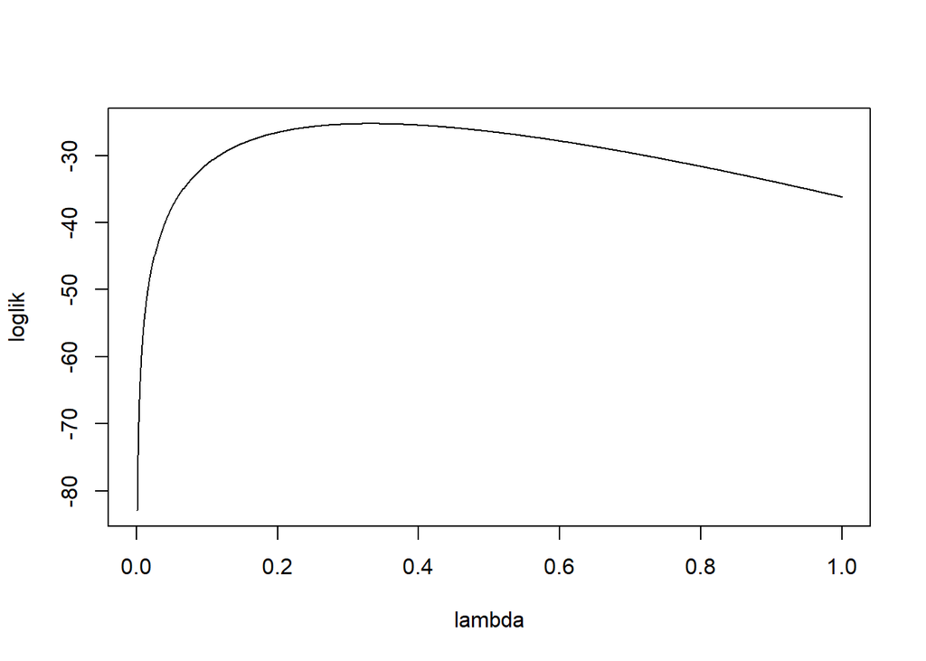

```r
X <- c(1.0, 5.2, 2.1, 9.3, 0.7, 1.5, 2.5, 0.9, 1.0, 3.8, 6.6, 1.6)
loglik.fun <- function(lambda) sum(dexp(X, rate=lambda, log=TRUE))
lambda <- seq(0,1,by=0.001)
loglik <- sapply(lambda, loglik.fun)
plot(lambda, loglik, type='l')
```

To find the score we take the derivative with respect to $\lambda$:
$$\mathrm{loglik}'(\lambda) = \frac{n}{\lambda} - \sum_{i=1}^n x_i.$$

The score is very useful for calculating the maximum likelihood estimate. We find the maximum likelihood estimate by finding the value of $\lambda$ where the score is zero. In this case $\hat\lambda$ is the value such that
$$\mathrm{loglik}'(\hat\lambda) = \frac{n}{\hat\lambda} - \sum_{i=1}^n x_i = 0,$$
so
$$\hat\lambda = n/\Big(\sum_{i=1}^n x_i\Big) = 1/\bar X$$
.

> Recipe for finding the MLE analytically
> 1. Find the density $f(x)$ of your model
> 2. Calculate $\log f (x)$
> 3. Find the log likelihood as $\sum_{i=1}^n\log f(x_i)$
> 4. Calculate the score by differentiating the log likelihood
> 5. Find the value of the parameter where the score is zero

To find the score for a likelihood, it is helpful to review the most important rules of differentiation:

$$\begin{align*}
f(x) = x^k \quad &\to \quad f'(x) = kx^{k-1} \\
f(x) = e^x \quad &\to \quad f'(x) = e^x \\
f(x) = \log(x) \quad &\to \quad f'(x) = 1/x \quad \textrm{(for $x>0$)}\\
f(x) = ag(x) \quad &\to \quad f'(x) = ag'(x) \\
f(x) = g(x) + h(x) \quad &\to \quad f'(x) = g'(x) + h'(x) \qquad (\textrm{sum rule}) \\
f(x) = g(x)h(x) \quad &\to \quad f'(x) = g'(x)h(x) + g(x)h'(x) \qquad \textrm{(product rule)}\\
f(x) = g[h(x)] \quad &\to \quad f'(x) = g'[h(x)]h'(x) \qquad \textrm{(chain rule)}
\end{align*}$$

$~$